# beatochess no. 15 (February 2026)

Beat Neuenschwander, neuenschwander.beat@gmail.com, https://github.com/beatochess/

# 1 Recent publications

## 1.1 Schach-Aktiv

I have dedicated the two following studies to **Michael Ehn**. Michael is a leading chess historian and author of many marvelous chess books. He has run the chess shop “Schach und Spiele” in Vienna over three decades. Whenever I have been visiting Vienna in recent years, I had the pleasure of meeting Michael in his shop. I hope Michael will continue his chess activities, and I am looking forward to his publications in the future.

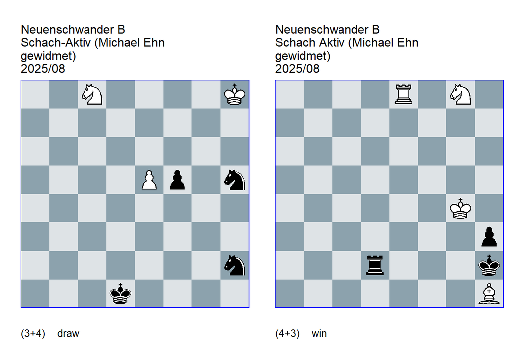

GBR: =0007.11h8d1 FEN: 2N4K/8/8/4Pp1n/8/8/7n/3k4 w - - 0 1

**1. e6 Ng4** (1… f4 2. e7 Nf6 3. Nd6 f3 4. Ne4 Ne8 5. Kg8 Ke2 6. Ng5 f2 7. Ne4) **2. e7 Ngf6** (2… Nhf6 3. Nd6 f4 4. Kg7 f3 5. Ne4) **3. e8=Q!** . (3. Nd6? f4 4. Ne4 f3) **3… Nxe8 4. Ne7 f4 5. Ng6 f3 6. Ne5 f2 7. Ng4 f1=N** Tree knights win against one… but **8. Nf6!** and stalemate or an exchange of a pair of knights follows **1/2-1/2**.

GBR: +0411.01g4h2 FEN: 4R1N1/8/8/8/6K1/7p/3r3k/7B w - - 0 1

**1. Ba8! Rg2+ 2. Kf3!** (2. Kf4? Rxg8 3. Rxg8 =) **2… Rg3+ 3. Ke4! Rg4+ 4. Kd5! Rg5+ 5. Kc6! Rg6+ 6. Kb7! Rg7+ 7. Ne7 1-0**.

## 1.2 van der Heijden 64-JT

The two studies were taken from the the provisional award.

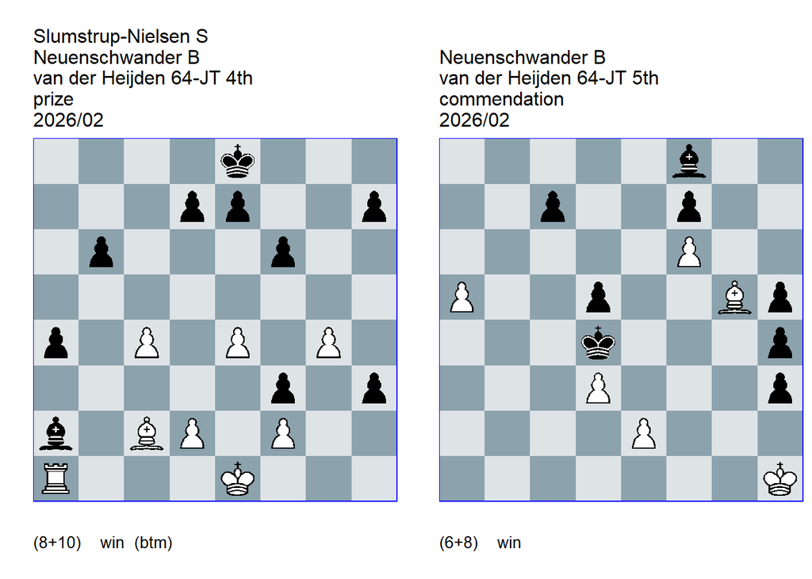

GBR: +0140.58e1e8 FEN: 4k3/3pp2p/1p3p2/8/p1P1P1P1/5p1p/b1BP1P2/R3K3 b Q - 0 1

**1… Bb1!** (1… h2 2. O-O-O +-) **2. Bd1 Bxe4 3. Bxa4 Bb1! 4. Bd1 Be4 5. Bb3** (5. Bc2? Bxc2 6. d4 Bd3 7. Kd2 Bxc4 =) **5… Bb1! 6. c5! e6** (6… h2 7. Ra8#) **7. Bd1 Be4 8. Ba4 Bb1! 9. Bxd7+! Kxd7 10. d3! Bxd3** (10… h2 11. Ra7+ Kc6 12. Rxh7 +-) **11. O-O-O!** (11. Kd2? Bg6 12. cxb6 Kc6 =) **1-0**.

GBR: +0040.46h1d4 FEN: 5b2/2p2p2/5P2/P2p2Bp/3k3p/3P3p/4P3/7K w - - 0 1

**1. Bh6!** (theme) (1. Kh2? Kc5 2. Kxh3 Kb5 3. Bd2 Ba3 4. Kxh4 c5 5. Kxh5 Bb4 6. Bg5 (6. Bc1 Bc3) 6… c4 7. dxc4+ dxc4 8. Kh6 Be1 9. Kg7 c3 10. Bc1 Bd2 11. Ba3 c2 =) (1. Bf4? Kc5 2. Bxc7 Kc6 =) (1. a6? Bc5 2. Bf4 Ba7 =) **1… Ba3** (1… Bd6 2. Bf4! (theme) 2… Kc5 3. Bxd6+ cxd6 4. Kh2 Kb5 5. Kxh3 Kxa5 6. Kxh4 Kb4 7. Kxh5 Kc5 8. Kh6 +-) (1… Bc5 2. Bf4 c6 3. Bc7 +-) **2. Bc1!** (theme) (2. Kh2? Bd6+ 3. Kxh3 c5 =) **2… Bb4** (2… Bf8 3. Bb2+ Ke3 4. d4 +-) **3. Bd2!** (theme) **3… Ba3 4. a6 Bc5 5. Be1! Ke3** (5… Ke5 main 6. d4+ Bxd4 7. Bc3! +- (theme) ) **6. Bf2+!** (theme) **6… Kxf2 7. e4** Six bishop sacrifices to mobilze a second passed pawn. **1-0**.

Harold’s comments for the two studies in the provisional award:

> “…It is a pity that the study starts with BTM, but it is not really disturbing here. All lines are crystal cleaar. This is a very good castling study!”

> “Before the award candidates were checked for possible anticipations, I assumed 6 bishop sacrifices (of which 2 in sublines) on different squares was a task record and hence it opted for a good spot in the award. I did recall a study by Ornstein, version by Timman (#023216), and that happened to have also 4+2 B-sacs. It has a similar matrix, but with the bishops running on white squares. In total 16 studies were found with 4 B-sacs or more in the main line. But the record holder is Hoch (#052812) that has 10 B-scas on 8 different squares, with 4 B-sacs in sublines. Moreover, its setting is very economical.”

## 1.3 Sinfonie Scacchistiche

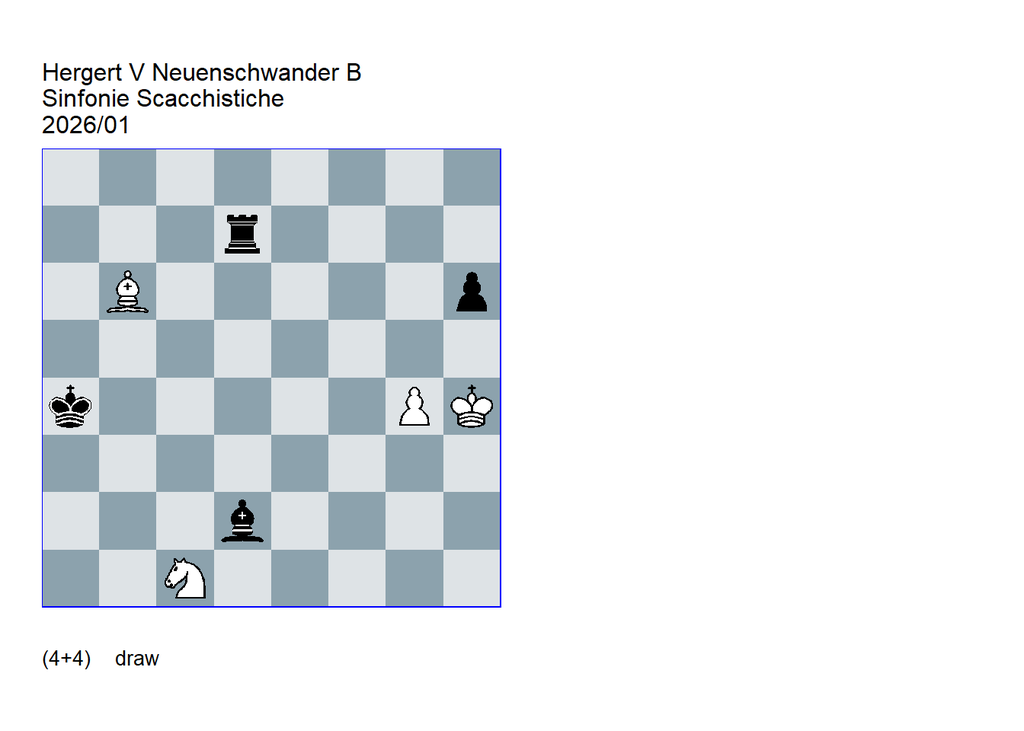

GBR: =0341.11h4a4 FEN: 8/3r4/1B5p/8/k5PK/8/3b4/2N5 w - - 0 1

**1. Ne2** The only escape for the knight. **1… Be1+** Black must permanently threaten a white piece, otherwise White draws easily. However, attacking bishop or knight at this point would leave White for choice. So, Black’s best try is to attack the king. (1… Bg5+ 2. Kh5!1) **2. Kh5!** (2. Kh3? surprisingly fails to 2… Kb5! -+ e.g. 3. Bg1 Kc4 4. Kg2 Rf7 5. Ng3 Rg7 6. Kf3 Bxg3 7. Kxg3 h5 -+) **2… Rd5+** Here, 2…Kb5 would be pointless. **3. g5** (3. Kxh6? Rd6+ 4. Kh7 Rxb6 -+) **3… Rxg5+ 4. Kxh6 Re5!** Double attack on knight and bishop (the latter by the threat of Re6+) (4… Bd2 5. Nc3+! Kb3 6. Ne4!1 ) (4… Rg2 5. Nf4 Bd2 6. Bc7 Rg4 (6… Rf2 7. Kg5!1) 7. Kh5!1) **5. Nd4** (5. Nf4? Bd2 -+) (5. Ng1? Re6+ 6. Kh5 Rxb6 -+) **5… Bf2** (5… Bc3 6. Kg6! Re4 7. Kf5!!1) **6. Kg6!** silent key move (6. Bc7? Rc5! -+ e.g. 7. Bb6 Rc4 -+) (6. Nf3? Re6+ 7. Kg7 Rxb6 -+) (6. Nc6? Re6+ -+) **6… Rd5** ( 6… Re4 7. Kf5!!1) **7. Nb5!!** (7. Nf5? Bxb6 -+) **7… Be1!** (7… Bxb6 8. Nc3+ Kb3 9. Nxd5!1) (7… Rxb5 8. Bxf2!1) (7… Kxb5 8. Bxf2!1) **8. Bf2!** (8. Nc7? Rd6+ 9. Kf5 Rxb6 -+) (8. Na7? Rd6+ 9. Kf5 Rxb6 -+) **8… Ba5!** (8… Bb4 9. Nc7!1) **9. Na7** (9. Nd4? Bb6 10. Ne2 Rd6+ 11. Kf5 Bxf2 -+) **9… Rd2 10. Be3** (10. Bc5? Rc2 11. Bd4 Bd8! 12. Kf5 Ka5 13. Ke6 Bb6 -+) **10… Rd3** (10… Re2 11. Bd4!1 e.g. 11… Re4 12. Bf2 (12. Bc5 Rc4 13. Be3!1) 12… Rf4 13. Be3!1) **11. Bc5!** (11. Bf2? Bb4! -+) (11. Bf4? Rc3! -+) (11. Bg1? Rg3+ 12. Kf5 Rxg1 -+) **11… Rc3** (11… Bb4 12. Bxb4!1) **12. Bd4 Rc4 13. Be3 Rc3 14. Bd4 Rc4 15. Be3 Bb4!** Final try to win. The move threatens 16…Bc5 -+. **16. Bb6!** (16. Kf5? Bc5 -+) (16. Kf6? Bc5 -+) **16… Bc5** (16… Ba5 17. Be3!1) **17. Nc8** Possible now as Black blocked the c-file. It’s finally a positional draw. **17… Bb4** (17… Ba3 18. Na7!1) (17… Kb5 18. Bxc5!1) (17… Bf8 18. Na7!1) **18. Na7 Ba5 19. Be3!!1 1/2-1/2**.

## 1.4 Die Schwalbe

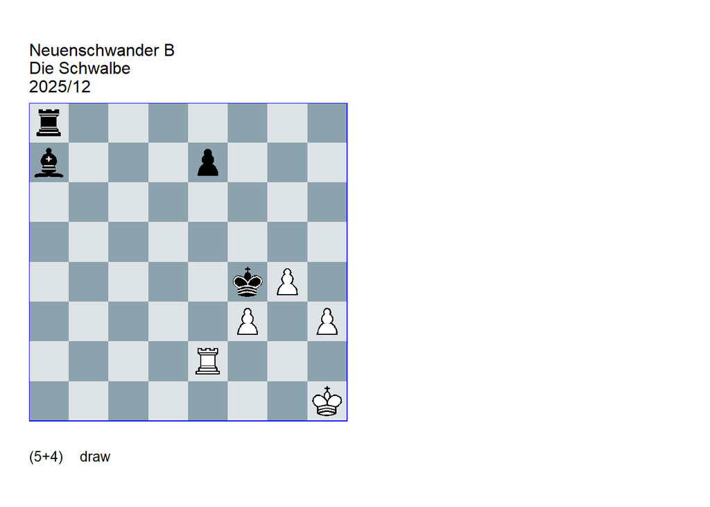

GBR: =0430.31h1f4 FEN: r7/b3p3/8/8/5kP1/5P1P/4R3/7K w - - 0 1

**1. Ra2** (1. Kg2? Be3!) **1… Kg3** (1… Kxf3 2. Ra3+ Kf4 3. Kg2) **2. f4!** (2. h4 Rb8 3. Rg2+ (3. Ra1 Rb2) 3… Kxf3 4. Kh2 Bf2) **2… Kxh3 3. f5!** (3. g5 Kg3 4. Ra3+ Kxf4 5. g6 (5. Kg2 Kxg5 6. Ra6 Kf5 7. Kf3 Ke5 8. Ke2 Kd5) 5… Rh8+) **3… Kg3 4. Ra3+ Kxg4 5. f6!** (5. Kg2? Kxf5 6. Kf3 Ke5 7. Ke2 Kd6 8. Kd3 Kc7 ) **5… exf6 6. Kg2** positional draw: Black cannot unpin without losing the pawn. **1/2-1/2**.

## 1.5 Phenix

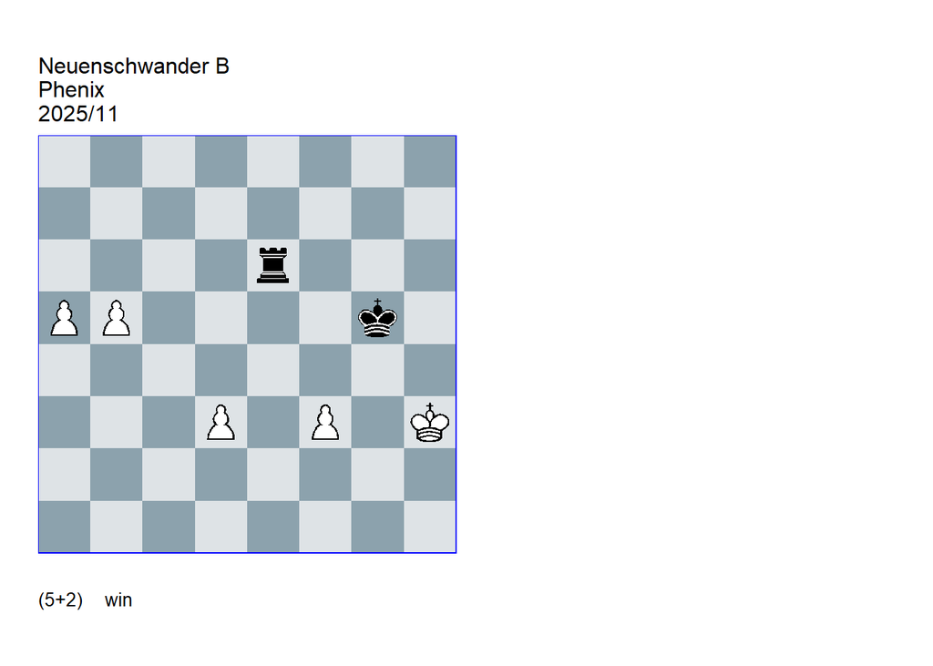

GBR: +0300.40h3g5 FEN: 8/8/4r3/PP4k1/8/3P1P1K/8/8 w - - 0 1

**1. b6!** ( Try: 1. a6? Kf4 2. a7 Re8 3. Kg2 (3. b6 Kxf3 4. Kh4 Kf4 5. Kh5 Kf5 6. Kh6 Kf6 7. Kh7 Re7+) 3… Re2+! 4. Kf1 Ra2 5. b6 Kxf3 6. Ke1 Ke3 7. Kd1 Kxd3 8. Kc1 Kc3 9. Kb1 Ra6 10. b7 Rb6+ 11. Kc1 Rh6! 12. Kd1 Kd3 13. Ke1 Ke3 14. Kf1 Kf3 15. Kg1 Rg6+ =) **1… Kf4 2. b7 Re8 3. Kg2!** This sets up the Roman theme (see move 9). (3. a6 Kxf3 4. Kh4 Kf4 etc. ) **3… Ke3** The other black resource. (3… Re2+ The defence in the try does not work here 4. Kf1 Rb2 5. a6 Kxf3 6. Ke1 Ke3 7. Kd1 Kxd3 8. Kc1 +- gains the decisive tempo ) **4. a6 Rg8+ 5. Kh3!** (5. Kf1? Kxf3 6. a7 Rh8 7. Ke1 Ke3 8. Kd1 Kxd3 9. Kc1 Kc3 10. Kb1 Rh1+ 11. Ka2 Rh2+ 12. Ka3 Rh1 13. Ka4 Kc4 14. Ka5 Kc5 15. Ka4 Kc4 =) **5… Kxf3 6. Kh4 Kf4 7. Kh5 Kf5 8. Kh6 Kf6 9. Kh7** Tempo gain (Roman theme). **9… Rb8 10. d4 Ke6 11. Kg6! Rg8+ 12. Kh6!** (12. Kh7 Rb8 =time loss ) (12. Kh5 Kf5 13. Kh6 Kf6 14. Kh7 Rb8 =time loss ) **12… Kf6 13. Kh7** Final decisive tempo gain. **13… Rb8 14. d5 Ke5 15. Kg6 Rg8+ 16. Kf7 Rb8 17. Ke7 Kxd5 18. Kd7 Kc5 19. Kc7 1-0**.

# 2 Comments and revisions

## 2.1 Prize winners

### 2.1.1 Nadareisvhili =0343.20h5h7 (1978). Changed solution

**2… Bd5** instead of **2… Ba2** keeps the contents of the study and makes it correct.

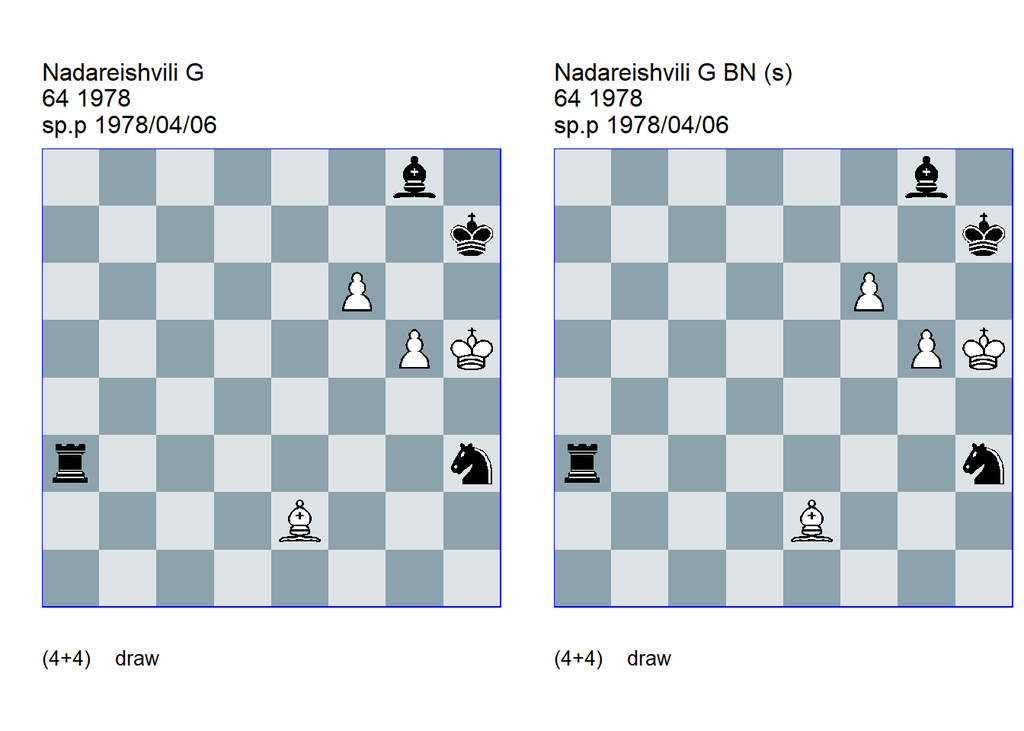

GBR: =0343.20h5h7 MR U2 FEN: 6b1/7k/5P2/6PK/8/r6n/4B3/8 w - - 0 1

(EG#04182); source: 64 no.14(509) 6-4-1978; U2: Garcia=M HHdbV 24-9-2011 **1. g6+ Kh8 2. Kh6 Ba2** (2… Bf7 3. g7+ (3. gxf7? Ra8 4. Bb5 Nf4 5. Be8 Ne6 6. Kg6 Ra6) 3… Kg8 4. Bd3 Ng5 5. Bh7+ Nxh7) **3. f7** (3. g7+? Kg8 4. f7+ Kxf7 5. Kh7 Ng5+) (3. Bc4! **cook** MG 3… Bxc4 4. f7 Bxf7 5. g7+ Kg8) **3… Bxf7 4. g7+** (4. gxf7? Ra8) **4… Kg8 5. Bd3! Bg6! 6. Bc4+** (6. Bxg6? Ra6!) **6… Bf7 7. Bd3 Ng5!** (7… Rxd3) **8. Bh7+! Nxh7 1/2-1/2**.

GBR: =0343.20h5h7 MR S FEN: 6b1/7k/5P2/6PK/8/r6n/4B3/8 w - - 0 1

(EG#04182); source: 64 no.14(509) 6-4-1978; changed solution: Neuenschwander=B beatochess (web) no.15 02/2026. **1. g6+ Kh8 2. Kh6 Bd5** (2… Bf7 3. g7+ (3. gxf7? Ra8 4. Bb5 Nf4 5. Be8 Ne6 6. Kg6 Ra6) 3… Kg8 4. Bd3 Ng5 5. Bh7+ Nxh7) **3. f7** (3. Bc4? Nf4!) **3… Bxf7 4. g7+** (4. gxf7? Ra8) **4… Kg8 5. Bd3! Bg6! 6. Bc4+** (6. Bxg6? Ra6!) **6… Bf7 7. Bd3 Ng5!** (7… Rxd3) **8. Bh7+! Nxh7 1/2-1/2**.

### 2.1.2 Sarychev =0047.12h5e2 (1977). Cook

**3… f3** gives Black a clear advantage.

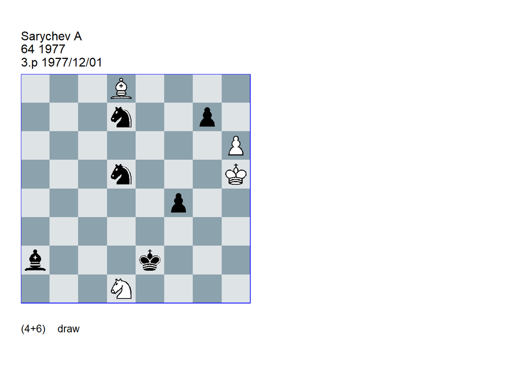

GBR: =0047.12h5e2 U3 FEN: 3B4/3n2p1/7P/3n3K/5p2/8/b3k3/3N4 w - - 0 1

(EG#04164); source: 64#76 no.48(491) 1-12-1977. U3: Neuenschwander=B beatochess (web) no.15 02/2026. **1. Nc3+ Nxc3 2. h7 Bf7+ 3. Kg5! Ne4+** (3… f3 **cook** **BN** 4. h8=Q f2 5. Qh2 Nd1 6. Bc7 Nf6 7. Bb6 Ne3 8. Bxe3 Kxe3 9. Qg3+ Ke2 10. Qe5+ Kf3 11. Qc3+ Kg2 12. Qb2 Bc4) **4. Kxf4 Nf8! 5. h8=Q Ng6+ 6. Kxe4 Nxh8 7. Bb6! Bg6+ 8. Kd5 Bf7+ 9. Ke4 Bg6+ 10. Kd5 Bf7+ 11. Ke4 Ng6** (11… g5 main 12. Kf5) (11… g6 main 12. Bd4) **12. Bd4 1/2-1/2**.

### 2.1.3 Kalinin & Grin +1007.23d3b3 (1979). Correction

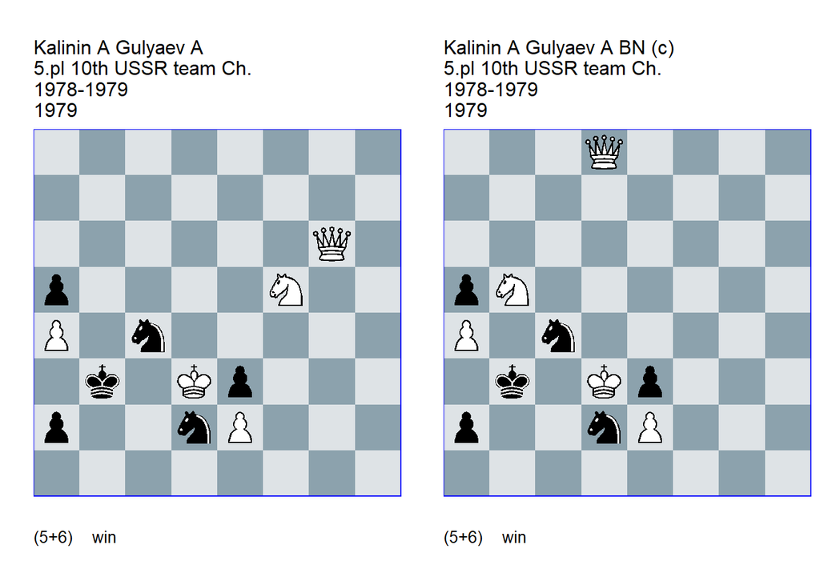

GBR: +1007.23d3b3 TT U1 FEN: 8/8/6Q1/p4N2/P1n5/1k1Kp3/p2nP3/8 w - - 0 1

(EG#04145); source: Bulletin USSR otb champ no.7 1979; U1: Garcia=M Estudios Artisticos de Ajedrez - V-15 2012 pseudonym: Grin=A **1. Nd4+** (1. Qg1! **cook** MG 1… Ne5+ 2. Kxe3 Kb2 3. Kxd2 a1=Q 4. Qxa1+ Kxa1 5. Kc3 Ka2 6. Nd6) **1… Kb2 2. Qg7 Kb1 3. Qg1+** (3. Nc2? Nb2+ 4. Kc3 Ne4+ 5. Kb3 Nd2+ 6. Kc3 Ne4+) **3… Kb2 4. Qa1+** (4. Nc2? Ne5+ 5. Kxe3 Kxc2 6. Qa1 Nec4+ 7. Kf2 Kb3) **4… Kxa1 5. Kc2 Na3+ 6. Kc1 Nf1** (6… Nab1 main 7. Nc2#) **7. Nb3# 1-0**.

GBR: +1007.23d3b3 TT C FEN: 3Q4/8/8/pN6/P1n5/1k1Kp3/p2nP3/8 w - - 0 1

(EG#04145); source: Bulletin USSR otb champ no.7 1979; pseudonym: Grin=A; correction: Neuenschwander=B beatochess (web) no.15 02/2026. **1. Nd4+ Kb2 2. Qh8 Kb1 3. Qh1+ Kb2 4. Qa1+ Kxa1 5. Kc2 Na3+ 6. Kc1 1-0**.

### 2.1.4 Bayastanov +0011.03e7d2 (1979). Correction

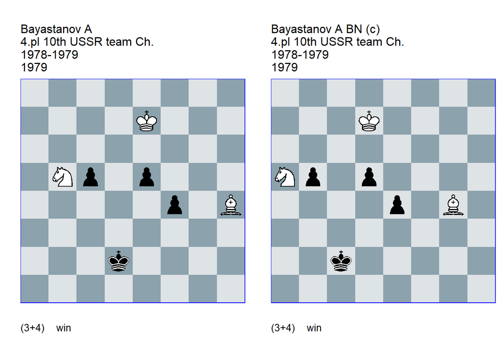

GBR: +0011.03e7d2 TT U3 FEN: 8/4K3/8/1Np1p3/5p1B/8/3k4/8 w - - 0 1

(EG#04137); source: Bulletin USSR otb champ no.7 1979; U3: Pallier=A EG=147 1/ 2007 **1. Kd6** (1. Bg5? Kd3 2. Kd6 f3 3. Bh4 e4) **1… e4 2. Kxc5** (2. Bg5? e3 3. Bxf4 c4 (3… Kd3? 4. Bg3 e2 5. Be1 Kc2 6. Nc3! (6. Ba5? c4 7. Nd4+ Kd3 8. Nf3 c3) ) ) **2… f3** (2… e3 main 3. Nd4 e2 4. Nf3+ Ke3 5. Ne1 (5. Nh2? Kd2 6. Nf3+ Ke3) 5… f3 6. Kd5 (6. Bg5+? Kf2 7. Bh4+ Ke3) 6… f2 7. Bg5#) **3. Nd4 Kd3 4. Kd5 Ke3 5. Kc4 f2** (5… Kd2! **cook** AP ) **6. Bg5# 1-0**.

GBR: +0011.03e7d2 TT C FEN: 8/3K4/8/Np1p4/4p1B1/8/2k5/8 w - - 0 1

(EG#04137); source: Bulletin USSR otb champ no.7 1979; correction: Neuenschwander=B beatochess (web) no.15 02/2026. **1. Kc6 d4 2. Kxb5 e3** (2… d3 3. Nc4 d2 4. Ne3+ Kd3 5. Nd1 e3 6. Kc5 e2 7. Bf5#) **3. Nc4 Kd3 4. Kb4 e2** (4… Kc2 5. Bh5) **5. Bf5# 1-0**.

### 2.1.5 Comay =0433.40e5g8 (1978). Correction

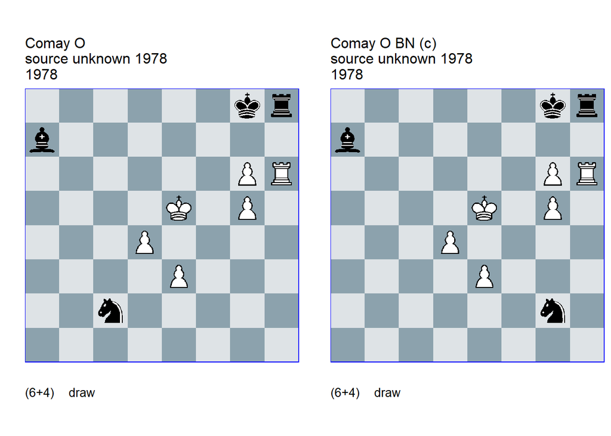

GBR: =0433.40e5g8 U1 FEN: 6kr/b7/6PR/4K1P1/3P4/4P3/2n5/8 w - - 0 1

(EG#04127); source: source unknown 1978; U1: Garcia=M HHdbV 22-9-2011; Ring ty: 2.p 13th Israel Ring ty 1978( Shahmat 11-12/1979) **1. Kf6** (1. Ke6 Nxe3 2. d5 Kg7 3. Rxh8 Kxh8 4. Kf7 Nf5 (4… Bd4? 5. d6 Nf5 6. d7 Bb6 7. Ke8 Nd6+ 8. Kf8 Nf5 9. Ke8) 5. g7+ Nxg7 6. d6 Kh7 7. d7 Bb6 8. g6+ Kh6 9. Ke7 Nf5+ 10. Kf6 Nd6 11. g7 (11. Ke7 Nb7 12. Kf7 Nd8+ 13. Kf6 Bc5) 11… Kh7 12. Ke7 (12. Ke6! **cook** MG 12… Nb7 13. Kf7 Nd8+ 14. Kf8 Ne6+ 15. Ke7 Nd8 16. Kf8 Bc5+ 17. Ke8 Bb6 18. Kf8) 12… Nf5+) **1… Nxe3 2. g7 Bxd4+** (2… Ng4+ 3. Kg6) (2… Rxh6+ 3. gxh6 Nd5+ 4. Kg6) **3. Kg6 Bxg7 4. Rh7 Bd4** (4… Rxh7) (4… Bf8 5. Rg7+ Bxg7) **5. Re7** (5. Rd7? Bc5 (5… Bb6? 6. Rd8+) 6. Rc7 Bb4 (6… Bd6? 7. Rg7+ Kf8 8. Rd7 Be7 9. Rd8+) 7. Rg7+ Kf8 8. Rb7 Rh4) **5… Kf8 6. Re8+** (6. Rf7+? Ke8 7. Re7+ Kd8) **1/2-1/2**.

GBR: =0433.40e5g8 C FEN: 6kr/b7/6PR/4K1P1/3P4/4P3/6n1/8 w - - 0 1

(EG#04127); source: source unknown 1978; Ring ty: 2.p 13th Israel Ring ty 1978( Shahmat 11-12/1979); correction: Neuenschwander=B beatochess (web) no.15 02/2026. **1. Kf6** (1. Ke6? Nh4) **1… Nxe3 2. g7 Bxd4+** (2… Ng4+ 3. Kg6) ( 2… Rxh6+ 3. gxh6 Nd5+ 4. Kg6) **3. Kg6 Bxg7 4. Rh7 Bd4** (4… Rxh7) (4… Bf8 5. Rg7+ Bxg7) **5. Re7** (5. Rd7? Bc5 (5… Bb6? 6. Rd8+) 6. Rc7 Bb4 (6… Bd6? 7. Rg7+ Kf8 8. Rd7 Be7 9. Rd8+) 7. Rg7+ Kf8 8. Rb7 Rh4) **5… Kf8 6. Re8+** (6. Rf7+? Ke8 7. Re7+ Kd8) **1/2-1/2**.

### 2.1.6 Dobrescu =0038.33g3c6 (1977). Cooks

In both mainlines, **2… bxa6** leads to a big black advantage.

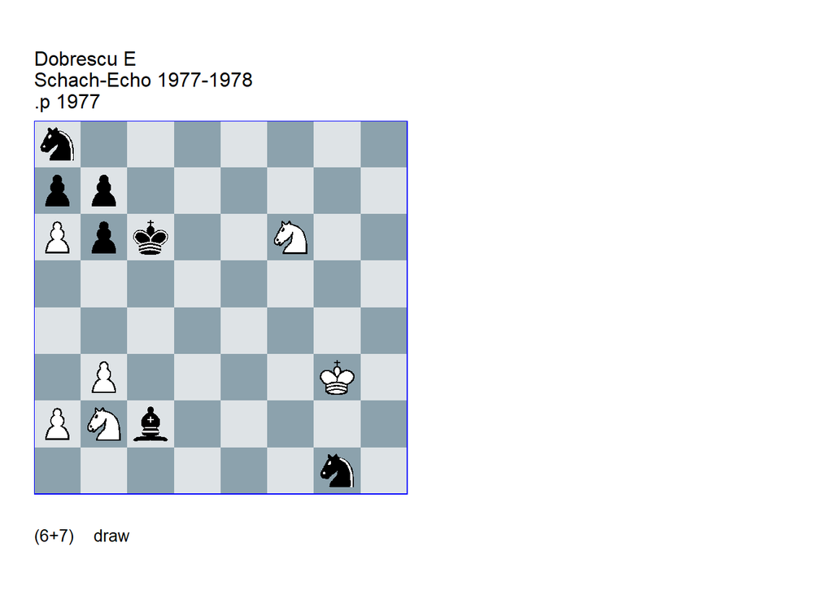

GBR: =0038.33g3c6 U3 FEN: n7/pp6/Ppk2N2/8/8/1P4K1/PNb5/6n1 w - - 0 1

(EG#04121); source: Schach-Echo#378 no.13-14 7/1977. U3: Neuenschwander=B beatochess (web) no.15 02/2026. **1. Nd5! Ne2+** (1… Bh7 main 2. Nc3! ( 2. Nf6? Bb1) 2… Bf5 (2… bxa6! **cook** **BN** 3. Kg2 Kc5 4. Kxg1 Kb4 -/+) 3. Nd5 Ne2+ (3… Be6 4. Nf4) 4. Kf3 (4. Kf2? Be4 5. Nb4+ Kb5) 4… Nd4+ 5. Ke3 Nc2+ 6. Kd2 Bh7 7. Nf6 Bg6 8. Nd5 Be4 9. Nf6 (9. Nc3 Bh7) 9… Bf5 10. Nd5 Nd4 11. Ke3 Nc2+ 12. Kd2) (1… Bb1 2. Nc3 (2. Nf4? Be4) 2… Bf5 (2… Bh7 3. Kg2) 3. Nd5 Be4 4. Nc3 Bf5 5. Nd5) **2. Kf3!** (2. Kf2? Be4 3. Nb4+ (3. Nf6 Nc3) 3… Kb5 4. Kxe2 Kxb4) **2… Ng1+** (2… bxa6! **cook** **BN** 3. Nb4+ Kc5 4. Nxc2 Nd4+ 5. Nxd4 Kxd4 -/+) **3. Kg3** (3. Kf2? Nh3+ 4. Kg3 Be4 5. Nc3 Bf5 6. Nb5 (6. Nd5 Be6) 6… Bd7 7. Nxa7+ Kc7 8. axb7 Kxb7 9. Nb5 Bxb5 10. Kxh3 Nc7) (3. Ke3? Bh7 4. Nf6 Bb1) **3… Ne2+ 4. Kf3 Nd4+ 5. Ke3 Nf5+ 6. Kf4** (6. Kf3? Bb1 7. Nc3 Nd4+ 8. Ke3 Nc2+ 9. Kd2 Na3) **6… Bb1 7. Nc3** (7. Nb4+? Kc7 8. Nd5+ Kb8 ) **7… Bc2 8. Nd5 Nd4 9. Ke3 Nf5+ 10. Kf4 1/2-1/2**.

### 2.1.7 Kuznetsov =3200.32a8a6 (1978). Cooks, changed solution

The two cooks can be fixed, although the end of the study is now a perpetual check instead of the intended positional draw.

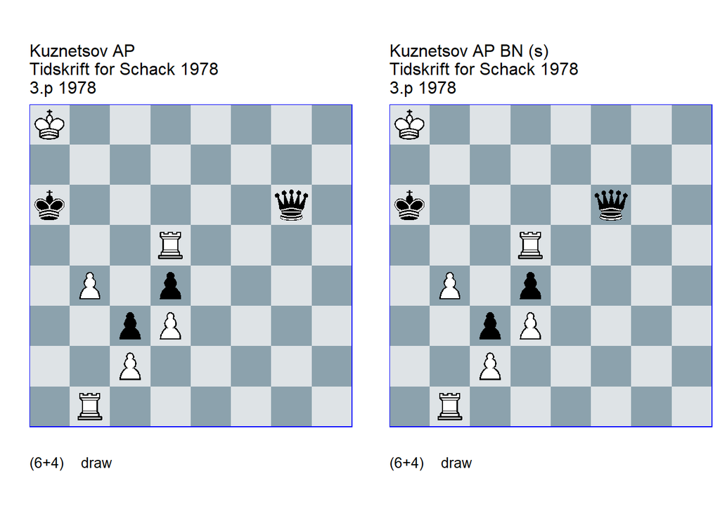

GBR: =3200.32a8a6 U2 U3 FEN: K7/8/k5q1/3R4/1P1p4/2pP4/2P5/1R6 w - - 0 1

(EG#04102); source: Tidskrift for Schack#2013 no.10 12/1978. U2 U3: Neuenschwander=B beatochess (web) no.15 02/2026. **1. Ra1+ Kb6 2. Ra6+! Kxa6 3. b5+ Ka5!** (3… Kb6 4. Rd6+ Qxd6) **4. b6+! Ka6! 5. b7 Qc6** (5… Qg8+! **cook** **BN** 6. b8=N+ Kb6 7. Rd6+ Kc5) **6. Rd7! Kb6 7. Re7! Qa4+** (7… Qd5 8. Rg7 Kc5 9. Rc7+ Kb4 10. Rc4+ Ka3 11. Rxd4) **8. Kb8 Qa2! 9. Rg7! Qe6 10. Ka8 Qc6 11. Re7** (11. Rg6! **cook** **BN** ) **11… Qa4+ 12. Kb8 Qa2 13. Rg7 1/2-1/2**.

GBR: =3200.32a8a6 S FEN: K7/8/k4q2/3R4/1P1p4/2pP4/2P5/1R6 w - - 0 1

(EG#04102); source: Tidskrift for Schack#2013 no.10 12/1978. changed solution: Neuenschwander=B beatochess (web) no.15 02/2026. **1. Ra1+ Kb6 2. Ra6+! Kxa6 3. b5+ Ka5!** (3… Kb6 4. Rd6+ Qxd6) **4. b6+! Ka6! 5. b7 Qc6 6. Rd7! Kb6 7. Re7! Qa4+** (7… Qd5 8. Rg7 Kc5 9. Rc7+ Kb4 10. Rc4+ Ka3 11. Rxd4) **8. Kb8 Qa2! 9. Rg7! Qe6 10. Ka8 Qd5 11. Rg6+ Kc7 12. Rg7+ Kb6 13. Rg6+ 1/2-1/2**.

### 2.1.8 Marwitz +0471.23f1h1 (1978). Cook, correction

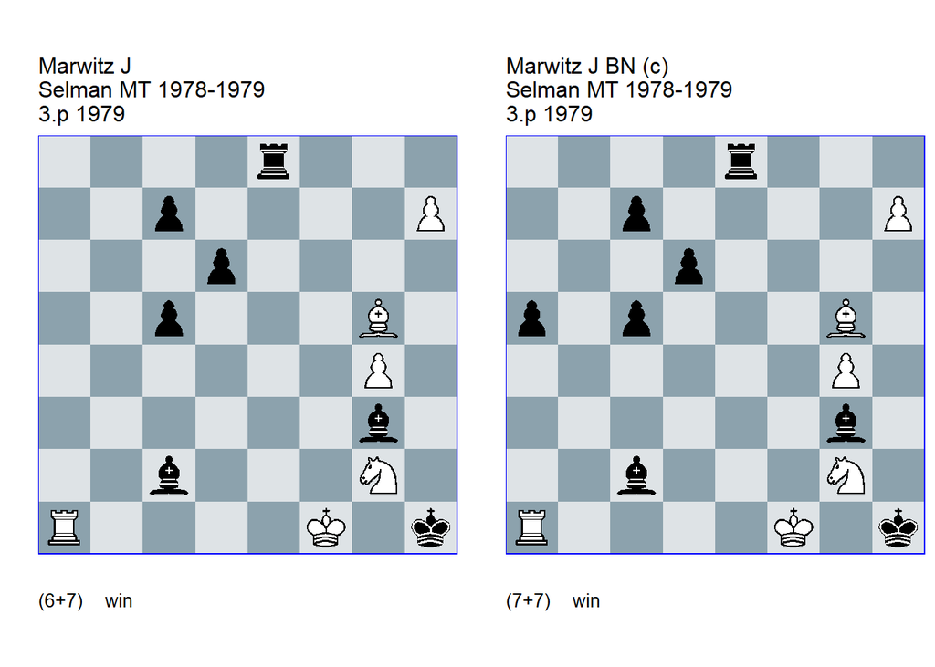

GBR: +0471.23f1h1 U2 FEN: 4r3/2p4P/3p4/2p3B1/6P1/6b1/2b3N1/R4K1k w - - 0 1

(EG#04021); source: Schakend Nederland#1681 no.3 3/1979; (ty also known as: KNSB ty 1978); U2: Van, der, Heijden=H HHdbVII 10-2-2024 **1. Ra3 Rf8+** (1… Kh2 2. Bf4! Rf8 (2… Bxf4 3. Nxf4) 3. h8=Q+ Rxh8 4. Rxg3) **2. Nf4!** (2. Bf4? Bxf4 3. h8=Q+ Rxh8 4. Nxf4 Be4) **2… Kh2!** (2… Bxf4 3. h8=Q+ Rxh8 4. Bxf4) **3. Ra2 Bxf4 4. Rxc2+** (4. Bxf4+? Rxf4+ 5. Ke1! (5. Ke2 Rf8 6. Rxc2 Rh8) 5… Re4+ (5… Rf8? 6. Rxc2+ Kg3 7. g5) 6. Kf2 Re8 7. Rxc2 Rh8! 8. Rd2! (8. Kf3+ Kh3 9. Rc1 Kh4 10. Kf4 Rf8+ 11. Ke4 Kg5! 12. Rh1 Rh8) 8… Kh3! (8… Rxh7 9. Rd5! Rf7+ 10. Rf5!) 9. Kf3 Rxh7 10. Rd5 Kh4 11. Kf4 Rf7+ 12. Rf5 Rxf5+! 13. gxf5 (13. Kxf5 c4) 13… Kh5) (4. h8=Q+? Rxh8 5. Bxf4+ Kh3 6. Rxc2 Kxg4) (4. Bf6! **cook** HH 4… Bd2 5. h8=Q+ Rxh8 6. Rxc2 Rb8 7. Rxd2+ Kg3 8. g5) **4… Bd2+!** (4… Kh3 5. Bxf4 Rxf4+ (5… Kxg4 6. Rg2+ Kf5 (6… Kxf4 7. Rf2+) 7. Rg8) 6. Kg1!) **5. Bf4+!** (5. Ke2? Bxg5) **5… Rxf4+ 6. Ke2 Rf8 7. Rxd2 Rh8 8. Kf3+** (8. Rd5? Kg3) **8… Kh3** (8… Kg1 9. Rd1+ Kh2 10. Rd5 Rxh7 11. Rh5+) **9. Rd5 Rxh7 10. Rh5+ Rxh5 11. gxh5 1-0**.

(EG#04021); source: Schakend Nederland#1681 no.3 3/1979; (ty also known as: KNSB ty 1978); correcction: Neuenschwander=B beatochess (web) no.15 02/2026. **1. Ra3 Rf8+** (1… Kh2 2. Bf4! Rf8 (2… Bxf4 3. Nxf4) 3. h8=Q+ Rxh8 4. Rxg3) **2. Nf4!** (2. Bf4? Bxf4 3. h8=Q+ Rxh8 4. Nxf4 Be4) **2… Kh2!** (2… Bxf4 3. h8=Q+ Rxh8 4. Bxf4) **3. Ra2 Bxf4 4. Rxc2+** (4. Bxf4+? Rxf4+ 5. Ke1! (5. Ke2 Rf8 6. Rxc2 Rh8) 5… Re4+ (5… Rf8? 6. Rxc2+ Kg3 7. g5) 6. Kf2 Re8 7. Rxc2 Rh8!) (4. h8=Q+? Rxh8 5. Bxf4+ Kh3 6. Rxc2 Kxg4) (4. Bf6? Bd2 5. h8=Q+ Rxh8 6. Rxc2 Ra8 7. Rxd2+ Kg3 8. g5 Kg4) **4… Bd2+!** (4… Kh3 5. Bxf4 Rxf4+ ( 5… Kxg4 6. Rg2+ Kf5 (6… Kxf4 7. Rf2+) 7. Rg8) 6. Kg1!) **5. Bf4+!** (5. Ke2? Bxg5) **5… Rxf4+ 6. Ke2 Rf8 7. Rxd2 Rh8 8. Kf3+** (8. Rd5? Kg3) **8… Kh3** ( 8… Kg1 9. Rd1+ Kh2 10. Rd5 Rxh7 11. Rh5+) **9. Rd5 Rxh7 10. Rh5+ Rxh5 11. gxh5 1-0**.

### 2.1.9 Kasparyan =0433.10c6e7 (1978). Cook, correction

**3. Rd2!** cooks the study.

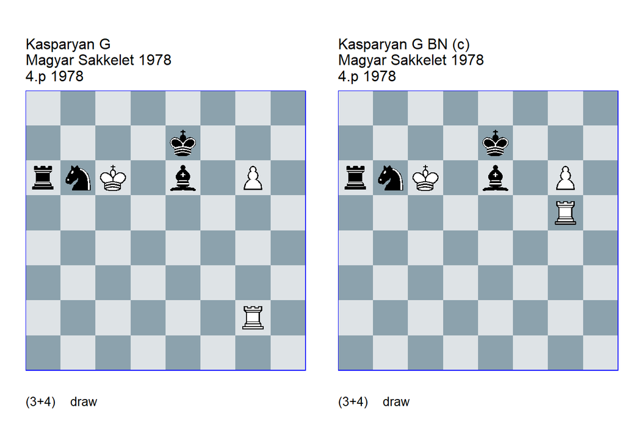

GBR: =0433.10c6e7 U2 FEN: 8/4k3/rnK1b1P1/8/8/8/6R1/8 w - - 0 1

(EG#03984); source: Magyar Sakkelet#1328 10/1978; Ring ty: 21/27.pl 14th USSR overall Ch. 1977-1978( Shakhmaty v SSSR 9/1982. U2: Neuenschwander=B beatochess (web) no.15 02/2026). **1. Kb7! Bc8+ 2. Kc7 Kf8 3. g7+** (3. Rd2! **cook** **BN** 3… Kg7 4. Rd8 Kh6 5. Rd2) **3… Kg8 4. Rg3!** (4. Rg5? Be6 5. Kb7 Bc4 6. Rc5 Bd3 7. Rc3 Na4 8. Rxd3 Nc5+) (4. Rb2? Ra7+) **4… Be6 5. Kb7 Bc4 6. Rc3!** ( 6. Rg4? Bd3 7. Rg3 Na4!) **6… Be2 7. Re3 Bf1 8. Rf3 Bc4 9. Rc3! Be2 10. Re3 Bf1 11. Rf3 1/2-1/2**.

GBR: =0433.10c6e7 C FEN: 8/4k3/rnK1b1P1/6R1/8/8/8/8 w - - 0 1

(EG#03984); source: Magyar Sakkelet#1328 10/1978; Ring ty: 21/27.pl 14th USSR overall Ch. 1977-1978( Shakhmaty v SSSR 9/1982. correction: Neuenschwander=B beatochess (web) no.15 02/2026). **1. Kb7! Bc8+ 2. Kc7 Kf8 3. g7+ Kg8 4. Rg3!** (4. Rb5? Nc4!) **4… Be6 5. Kb7 Bc4 6. Rc3!** (6. Rg4? Bd3 7. Rg3 Na4!) **6… Be2 7. Re3 Bf1 8. Rf3 Bc4 9. Rc3! Be2 10. Re3 Bf1 11. Rf3 1/2-1/2**.

### 2.1.10 Umnov =0700.34c8h6 (1978). Cook, correction

The ending with two rooks and passed h-pawn arising after **1… Rg7+** gives Black a clear advantage.

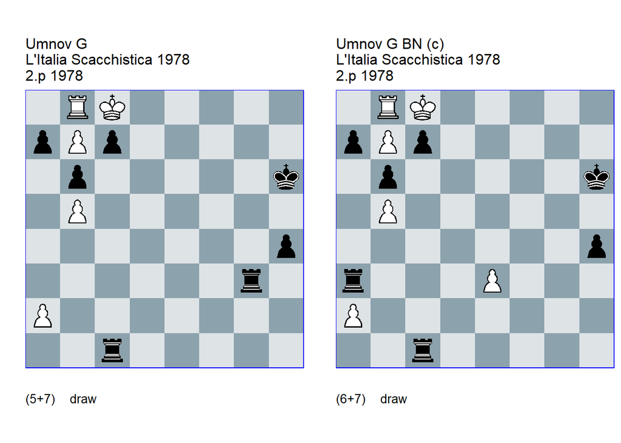

GBR: =0700.34c8h6 U3 FEN: 1RK5/pPp5/1p5k/1P6/7p/6r1/P7/2r5 w - - 0 1

(EG#03971); source: L’Italia Scacchistica#239 no.876 10/1978; Ring ty: 35/42. pl 14th USSR overall Ch. 1977-1978( Shakhmaty v SSSR 9/1982). U3: Neuenschwander=B beatochess (web) no.15 02/2026. **1. Kd7!** (1. Ra8? Rg7 2. Rxa7 Rf1 3. b8=Q Rf8+ 4. Kb7 Rxb8+ 5. Kxb8 Kg5 6. Rxc7 Rxc7 7. Kxc7 h3 8. Kxb6 h2 9. Ka7 h1=Q 10. b6 Qb1 11. a4 Qb4) **1… Rd1+!** (1… Rg7+! **cook** **BN** 2. Ke6 Kg5 3. Rh8 Rd1 4. Rh5+ Kxh5 5. b8=Q Kg4 -/+) **2. Ke6 Re3+ 3. Kf5 Rf1+ 4. Kg4 Rg3+ 5. Kxh4 Rg8! 6. Rxg8 Rh1+ 7. Kg4 Rg1+ 8. Kf5 Rxg8 9. Ke6 Rb8 10. Kd7 Rxb7 11. Kc8! c5! 12. bxc6! Rg7 13. Kb8 b5 14. c7 Rg8+ 15. Kxa7! 1/2-1/2**.

GBR: =0700.44c8h6 C FEN: 1RK5/pPp5/1p5k/1P6/7p/r3P3/P7/2r5 w - - 0 1

(EG#03971); source: L’Italia Scacchistica#239 no.876 10/1978; Ring ty: 35/42. pl 14th USSR overall Ch. 1977-1978( Shakhmaty v SSSR 9/1982).; correction: Neuenschwander=B beatochess (web) no.15 02/2026. **1. Kd7!** (1. Ra8? Rxe3) **1… Rd1+! 2. Ke6 Rxe3+ 3. Kf5 Rf1+ 4. Kg4 Rg3+ 5. Kxh4 Rg8! 6. Rxg8 Rh1+ 7. Kg4 Rg1+ 8. Kf5 Rxg8 9. Ke6 Rb8 10. Kd7 Rxb7 11. Kc8! c5! 12. bxc6! Rg7 13. Kb8 b5 14. c7 Rg8+ 15. Kxa7! 1/2-1/2**.

### 2.1.11 Minev =0560.24g6g8 (1974). Cook

The version without the black knight is cooked.

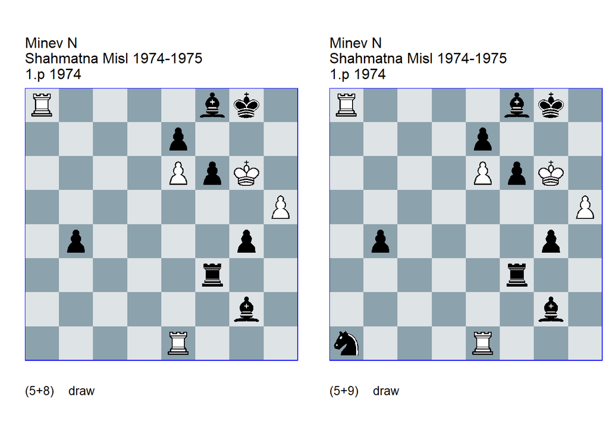

GBR: =0560.24g6g8 V U2 FEN: R4bk1/4p3/4PpK1/7P/1p4p1/5r2/6b1/4R3 w - - 0 1

(EG#03783); source: Shahmatna Misl#28 no.3 3 /1974; (v): (source unknown 0000). U2: Neuenschwander=B beatochess (web) no.15 02/2026. **1. Rd1! Rd3 2. Rxf8+ Kxf8 3. Rxd3 Be4+ 4. Kh6 Bc6** (4… Bxd3) **5. Rd8+** (5. Rd4! +- **cook** **BN** ) **5… Be8 6. Rd4 b3 7. Rxg4 b2 8. Rg8+ Kxg8 1/2-1/2**.

GBR: =0563.24g6g8 FEN: R4bk1/4p3/4PpK1/7P/1p4p1/5r2/6b1/n3R3 w - - 0 1

(EG#08468); source: Shahmatna Misl#28 no.3 3/1974 **1. Rd1! Rd3 2. Rxf8+ Kxf8 3. Rxd3 Be4+** (3… Bc6 4. Rd8+ Be8+ 5. Rxe8+ Kxe8 6. h6) **4. Kh6 Bc6** (4… Bxd3) **5. Rd8+ Be8 6. Rd4 Nb3** (6… b3 7. Rxg4 b2 8. Rg8+ Kxg8) **7. Rxg4 Nc5! 8. Rg8+ Kxg8 1/2-1/2**.

[figure not shown]

GBR: =0033.10e3b5 TT (U2) FEN: 6b1/8/7P/1k6/8/2n1K3/8/8 w - - 0 1

(EG#03782); source: Ukraine Team Ch 1978. (U2): Neuenschwander=B beatochess (web) no.15 02/2026. **1. Kd4 Kb4 2. Ke5 Bh7 3. Kf6 Ne4+ 4. Kg7 Ng5 5. Kf6 Ne4+ 6. Kg7** (6. Kf7 minor **dual** ) **6… Ng5 7. Kf6 1/2-1/2**.

GBR: =0033.10e3b5 TT C FEN: 6b1/8/7P/8/8/2n1K3/8/4k3 w - - 3 3

(EG#03782); source: Ukraine Team Ch 1978. correction: Neuenschwander=B beatochess (web) no.15 02/2026. **3. Kd4 Kd2 4. Ke5 Bh7 5. Kf6 Ne4+ 6. Kg7 Ng5 7. Kf6 Ne4+ 8. Kg7 Ng5 9. Kf6 1/2-1/2**.

### 2.1.13 Priedniks =0131.24a3b5 (1977). Correction

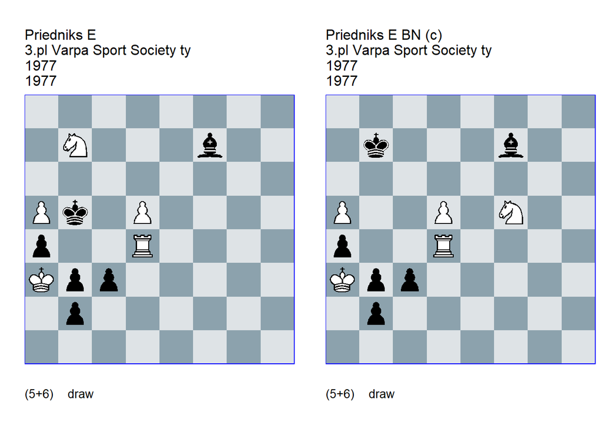

GBR: =0131.24a3b5 U2 FEN: 8/1N3b2/8/Pk1P4/p2R4/Kpp5/1p6/8 w - - 0 1

(EG#03767); source: Varpa Sport Society ty 1977; U2: Garcia=M HHdbV 6-2-2009 **1. Rb4+ Ka6 2. Nd6** (2. Rb6+! **cook** MG 2… Ka7 3. Nd6 b1=Q 4. Nb5+ Ka8 5. Nc7+) **2… Bxd5** (2… b1=Q 3. Rb6+ Ka7 4. Nb5+ Ka8 5. Nc7+) **3. Rb6+** (3. Nb5? b1=N+ 4. Kxa4 c2 5. Nc7+ Ka7 6. Nb5+ Kb8 7. Nc3+ Ka8 8. Ne2 Nc3+) **3… Kxa5 4. Nc4+ Bxc4 5. Rxb3 c2 6. Rxb2 c1=R 7. Rc2 Rxc2 1/2-1/2**.

GBR: =0131.24a3b5 C FEN: 8/1k3b2/8/P2P1N2/p2R4/Kpp5/1p6/8 w - - 0 1

correction: Neuenschwander=B beatochess (web) no.15 02/2026. **1. Nd6+ Ka6** ( 1… Ka8 2. Rc4 b1=Q 3. Rc8+ Ka7 4. Rc7+ Ka6 5. Rc6+) **2. Rb4 Bxd5** (2… b1=Q 3. Rb6+ Ka7 4. Nb5+ Ka8 5. Nc7+) **3. Rb6+** (3. Nb5? b1=N+ 4. Kxa4 c2 5. Nc7+ Ka7 6. Nb5+ Kb8 7. Nc3+ Ka8 8. Ne2 Nc3+) **3… Kxa5 4. Nc4+ Bxc4 5. Rxb3 c2 6. Rxb2 c1=R 7. Rc2 Rxc2 1/2-1/2**.

### 2.1.14 Katsnelson =0031.22b8h4 (1977). Cook

The version is cooked by **1. Kb7**.

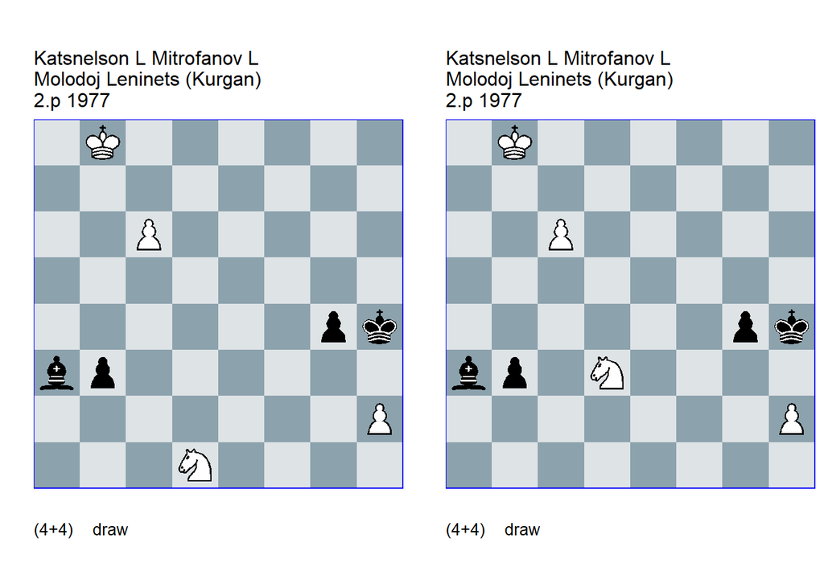

GBR: =0031.22b8h4 FEN: 1K6/8/2P5/8/6pk/bp6/7P/3N4 w - - 0 1

(EG#03751). **1. Kc7! b2! 2. Nxb2 Bxb2 3. Kd6! Bc1 4. Ke5 Kg5 5. Ke4 Bf4 6. h4+! gxh3 7. Kf3 1/2-1/2**.

GBR: =0031.22b8h4 V U1 FEN: 1K6/8/2P5/8/6pk/bp1N4/7P/8 w - - 0 1

U1: Neuenschwander=B beatochess (web) no.15 02/2026. **1. Kc7!** (1. Kb7? Bd6!) (1. Kb7! **cook** **BN** 1… Bd6 2. Kb6 Kh3 3. Kb5 Kxh2 4. Kc4 g3 5. Kxb3 Kg2 6. Kc4 Kf1 7. Kd5 g2 (7… Bb8 8. Ne5 g2 9. Nf3 Kf2 10. Ke4) 8. Kxd6 g1=Q 9. c7 Qg4 10. Kc6) **1… b2** (1… Bb4 2. Kb6 Bd6 3. Kb5 Bxh2 4. Kc4 Bc7 5. Kxb3 Kg3 6. Kc2 Kf3 7. Kd1 g3 8. Ne1+) **2. Nxb2 Bxb2 3. Kd6 Bc1 4. Ke5 Kg5 5. Ke4** (5. h4+? gxh3 6. Ke4 h2) **5… Bf4 6. h4+! gxh3 7. Kf3 h2 8. Kg2 1/2-1/2**.

### 2.1.15 Gurgenidze +3805.31a8b1 (1977). Correction

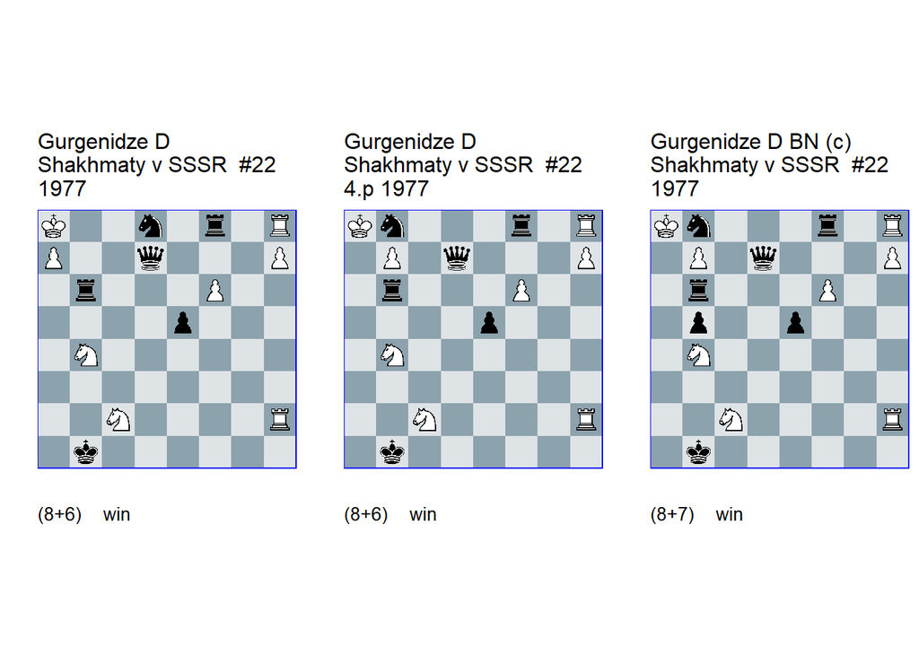

GBR: +3805.31a8b1 U2 FEN: K2n1r1R/P2q3P/1r3P2/4p3/1N6/8/2N4R/1k6 w - - 0 1

Shakhmaty v SSSR/6. U2: Shakhmaty v SSSR/12 1977. **1. Na3+ Kc1** (1… Ka1 2. Ra2#) **2. Na2+ Kd1 3. Nc3+ Ke1** (3… Kc1 4. Rc2#) **4. Nc2+ Kf1 5. Ne3+ Kg1** (5… Ke1 6. Re2#) **6. Rg8+! Qg7! 7. Ne2+** (7. Rxg7+? Kxh2 8. Rg8 Ne6+ 9. Rxf8 Nc7#) (7. fxg7! **cook** 7… Ne6+ 8. gxf8=Q+) **7… Kxh2 8. h8=Q+ Qxh8 9. Nf1+!** (9. Rg2+? Kh3 10. Rg3+ Kh4 11. Rg4+ Kh5 12. Ng3+ Kh6 13. Ngf5+ Kh7) **9… Kh3** (9… Kh1 10. Rg1#) **10. Ng1+ Kh4 11. Nf3+ Kh5** (11… Kh3 12. Rg3#) **12. Ng3+ Kh6 13. Nf5+ Kh7** (13… Kh5 14. Rg5#) **14. Ng5+! Kxg8 15. Ne7# 1-0**.

GBR: +3805.31a8b1 C U2 FEN: Kn3r1R/1P1q3P/1r3P2/4p3/1N6/8/2N4R/1k6 w - - 0 1

Shakhmaty v SSSR/6 (EG#03723). correction: Shakhmaty v SSSR/11 1978. U2: Hornecker=S HHdbIV#44763 30-6-2005. **1. Na3+! Kc1 2. Na2+** (2. Rh1+! **cook** NH 2… Kb2 3. Nc4+ Kb3 4. Nxb6) **2… Kd1 3. Nc3+ Ke1 4. Nc2+ Kf1 5. Ne3+ Kg1 6. Rg8+ Qg7! 7. Ne2+!** (7. Rxg7+? Kxh2) (7. fxg7? Ra6#) **7… Kxh2 8. h8=Q+! Qxh8 9. Nf1+ Kh3 10. Ng1+ Kh4 11. Nf3+ Kh5 12. Ng3+ Kh6 13. Nf5+ Kh7 14. Ng5+! Kxg8 15. Ne7# 1-0**.

GBR: +3805.32a8b1 C FEN: Kn3r1R/1P1q3P/1r3P2/1p2p3/1N6/8/2N4R/1k6 w - - 0 1

correction: Neuen6schwander=B beatochess (web) no.15 02/2026. **1. Na3+! Kc1 2. Na2+ Kd1 3. Nc3+ Ke1 4. Nc2+ Kf1 5. Ne3+ Kg1 6. Rg8+ Qg7! 7. Ne2+!** (7. Rxg7+? Kxh2) (7. fxg7? Ra6#) **7… Kxh2 8. h8=Q+! Qxh8 9. Nf1+ Kh3 10. Ng1+ Kh4 11. Nf3+ Kh5 12. Ng3+ Kh6 13. Nf5+ Kh7 14. Ng5+! Kxg8 15. Ne7# 1-0**.

### 2.1.16 Afek =0340.53a7c8 (1978). Correction

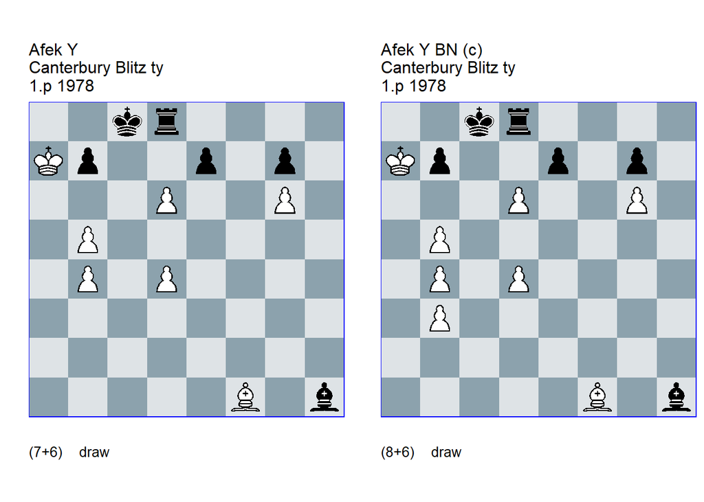

GBR: =0340.53a7c8 U3 FEN: 2kr4/Kp2p1p1/3P2P1/1P6/1P1P4/8/8/5B1b w - - 0 1

(EG#03596). U3: ARVES website#022 6-5-2005. **1. Bh3+ e6** (1… Rd7 2. dxe7) **2. Bxe6+ Rd7 3. d5 Bxd5** (3… Be4 4. Bxd7+ Kxd7 5. Kxb7 Bxg6 6. Ka7 Be4 7. b6 g5 8. b7) **4. Bxd5 b6+** (4… Rxd6 5. Bxb7+ Kc7 6. Be4 Rf6! **cook** 7. Bb1 (7. Bc6 Rf4) 7… Rb6 8. Bd3 Rb8 9. Be2 Rb7+ 10. Ka6 Rb6+ 11. Ka5 Rxg6) **5. Bb7+** (5. Kxb6? Rxd6+ 6. Ka7 Rxg6) **5… Rxb7+** (5… Kd8 6. Kxb6 Rxd6+ 7. Ka7 Kc7 (7… Rxg6 8. b6) 8. Be4) **6. Ka8 Rb8+ 7. Ka7 Rb7+ 8. Ka8 1/2-1/2**.

GBR: =0340.63a7c8 C FEN: 2kr4/Kp2p1p1/3P2P1/1P6/1P1P4/1P6/8/5B1b w - - 0 1

correction: Neuenschwander=B beatochess (web) no.15 02/2026. **1. Bh3+ e6** (1… Rd7 2. dxe7) **2. Bxe6+ Rd7 3. d5 Bxd5** (3… Be4 4. Bxd7+ Kxd7 5. Kxb7 Bxg6 6. Ka7 Be4 7. b6 g5 8. b7) **4. Bxd5 b6+** (4… Rxd6 5. Bxb7+ Kc7 6. Be4 Rf6 7. Bc6) **5. Bb7+** (5. Kxb6? Rxd6+ 6. Ka7 Rxg6) **5… Rxb7+** (5… Kd8 6. Kxb6 Rxd6+ 7. Ka7 Kc7 (7… Rxg6 8. b6) 8. Be4) **6. Ka8 Rb8+ 7. Ka7 Rb7+ 8. Ka8 1/2-1/2**.

### 2.1.17 Kralin =0086.30b5f8 (1977). Cooks

White has different ways to a draw in the second mainline **3… Nc2**.

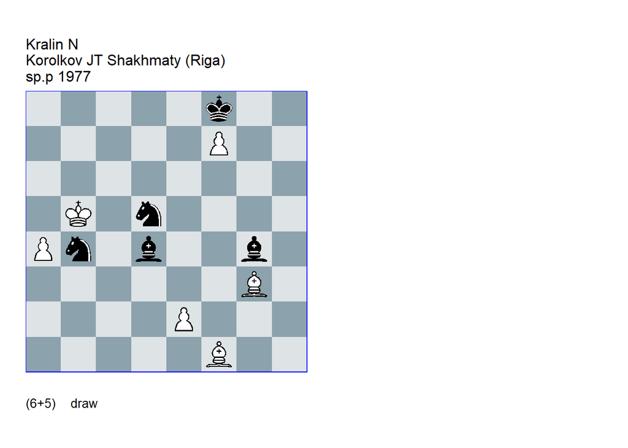

GBR: =0086.30b5f8 U2 FEN: 5k2/5P2/8/1K1n4/Pn1b2b1/6B1/4P3/5B2 w - - 0 1

Shakhmaty (Riga)/6 1978 (EG#03586). U2: Neuenschwander=B beatochess (web) no.15 02/2026. **1. e4 Ne3 2. Bc4 Nxc4 3. Kxc4 Nc6** (3… Nc2 main 4. Kd3 Bd1 5. Kd2 (5. a5! **cook** **BN** ) (5. Bf4! **cook** **BN** ) 5… Ne3 6. Kd3 Nc2 7. Kd2 Ne3 8. Kd3 Bb6 9. a5 Ba7 10. Bf2 Bc2+ 11. Ke2 Bd1+ 12. Kd3 Bc2+ 13. Ke2) **4. Kd5 Bd7 5. Kd6 Nb8 6. Kc7 Ba7 7. Kb7 Nc6 8. Kc7 Nb8 9. Kb7 1/2-1/2**.

### 2.1.18 Benko +0430.20f1a7 (1977). Comment

**1… Rf3+** should be demoted to a sideline. This is consistent with **EG 55** (study number 3553), which reports only one mainline.

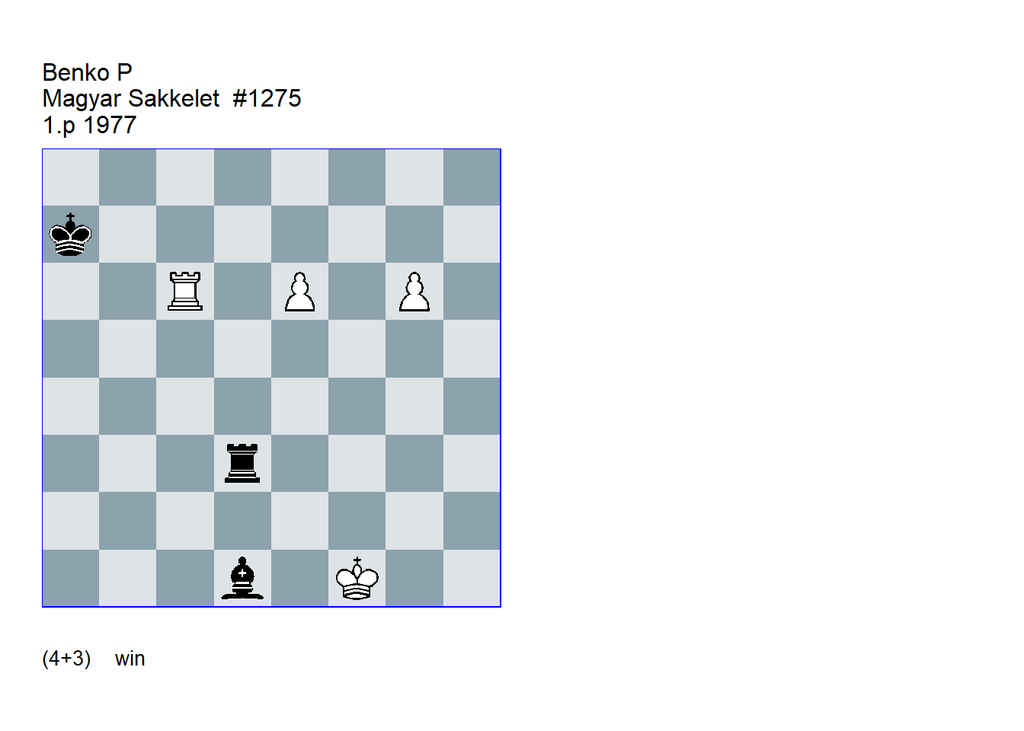

GBR: +0430.20f1a7 U2 S FEN: 8/k7/2R1P1P1/8/8/3r4/8/3b1K2 w - - 0 1

Magyar Sakkelet/12 (EG#03553). solution: Benko=P Chess Life=9 9/1980. U2/comment: Neuenschwander=B beatochess (web) no.15 02/2026. **1. e7!** (1. g7? Rg3 (1… Rd8? 2. Rd6 Rg8 3. Rxd1 Rxg7 4. Rd7+ Rxd7 5. exd7) 2. e7 Bh5 3. Rg6 Rxg6! (3… Bxg6? 4. Kf2!) 4. e8=Q Rf6+ 5. Kg1 (5. Ke1 Bxe8 6. g8=Q Bd7!) 5… Bxe8 6. g8=Q Rg6+) (1. Rc7+? Kb6 2. e7 (2. g7 Rg3 3. e7 Bh5) 2… Re3 3. g7 Kxc7 4. g8=Q Be2+ 5. Kf2 Rxe7) **1… Re3** (1… Rf3+ maindemote to sideline? **BN** 2. Ke1! (2. Kg1? Rg3+) (2. Kg2? Re3 3. g7 Bb3 4. Rc7+ Kb6 5. Rc3 Bd5+) (2. Kg1! **cook** **BN** 2… Rg3+ 3. Kh2 Re3 4. Rc1 Bf3 (4… Bb3 5. Ra1+ Kb6 6. Rb1) (4… Bh5 5. g7 Bf7 6. e8=Q Rxe8 7. Rc7+ ) 5. Rc3) 2… Re3+ 3. Kxd1 Rxe7 4. Rc5! (4. Rf6? Re5! (4… Re3? 5. Kd2 Rg3 6. Ke2 Kb7 7. Kf2 Rg5 8. Kf3 Kc7 9. Kf4 Rg1 10. Kf5 Kd7 11. Rf7+) ( 4… Re4? 5. Rf7+ Kb6 6. g7 Rg4 7. Ke2 Kc6 8. Kf3 Rg1 9. Kf4 Kd6 10. Kf5) 5. g7 Rg5 6. Rf7+ Kb6 7. Ke2 Kc6 8. Kf3 Kd6 9. Kf4 Ke6) (4. Kd2? Re4! (4… Re5? 5. Rc7+ Kb6 6. Rh7 Kc6 7. g7 Rg5 8. Ke3 Kd6 9. Kf4 Rg1 10. Kf5) ) 4… Kb6 5. Rg5 Rg7 6. Ke2 Kc6 7. Kf3 Kd6 8. Kg4 Ke7 9. Kh5 Kf6 (9… Kf8 10. Kh6 Ra7 11. Rb5) 10. Kh6) **2. g7** (2. Rc7+? Kb6 3. g7 Kxc7 4. g8=Q Be2+ 5. Kf2 Rxe7 ) **2… Bb3 3. Rc7+!** (3. Re6? Rxe6! (3… Bxe6? 4. Kf2) 4. g8=Q Bc4+! (4… Rf6+? 5. Kg1! Bxg8 6. e8=Q) 5. Kf2 Re2+ 6. Kf3 Bxg8 7. Kxe2 Bf7) **3… Ka6!** (3… Kb6 4. Rc3!) **4. Kf2! Re4 5. Rc6+!** (5. Kf3? Re1 6. Rc6+ Ka5 7. Re6 Rxe6 8. g8=Q Rf6+ 9. Kg3 Bxg8 10. e8=Q Rf1) **5… Ka5 6. Re6! Rxe6** ( 6… Bxe6 7. e8=Q) **7. g8=Q Rf6+ 8. Kg1!** (8. Ke3? Bxg8 9. e8=Q Re6+) (8. Kg3? Bxg8 9. e8=Q Rf1! (9… Be6? 10. Qd8+) 10. Qe5+ Kb4 11. Kg2 Bc4) ( 8. Kg2? Bxg8 9. e8=Q Bd5+ 10. Kg1 Rb6) **8… Bxg8 9. e8=Q Bd5** eg **10. Qd8+ 1-0**.

### 2.1.19 Pospisil =0443.23g5h7 (1976). Cook

It is unclear how White holds after **6… Ra4!**.

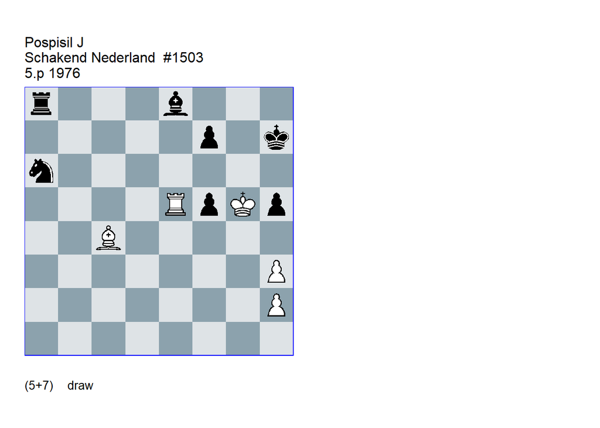

GBR: =0443.23g5h7 U3 FEN: r3b3/5p1k/n7/4RpKp/2B5/7P/7P/8 w - - 0 1

Schakend Nederland/4 (EG#03532). U3: Neuenschwander=B beatochess (web) no.15 02/2026. **1. Re7 Kg7** (1… Nc5 2. Bxf7 Bxf7 3. Rxf7+ Kg8 4. Rxf5 Ne6+ 5. Kh6! Ra7 6. Rf6 Ng7 7. Rg6) **2. Bxa6 Kf8 3. Bb7 Ra7 4. Rc7 Kg7 5. Rc8 Bd7 6. Rb8 f6+** (6… Ra4 **cook** **BN** 7. Ra8 Rb4 8. Bd5 Rd4 9. Ba2 f4 +/-) **7. Kxh5** (7. Kf4? Ra4+ 8. Kg3 Rb4) **7… Ra4! 8. Ra8!** (8. Bd5? Rd4! 9. Bb3 (9. Bg2 Be6!) 9… Bc6!) **8… Rb4 9. Bd5 Rd4 10. Ba2! Rd3 11. Kh4** (11. h4? Bc6 12. Ra7+ Rd7 13. Ra3 Re7!) **11… f4 12. Rg8+ Kh7 13. Bb1 Kxg8 14. Bxd3 1/2-1/2**.

### 2.1.20 Dobrescu =3445.11h1b8 (1976). Cooks

**1… Qe8!** and **10… Kxc7!** cook the study.

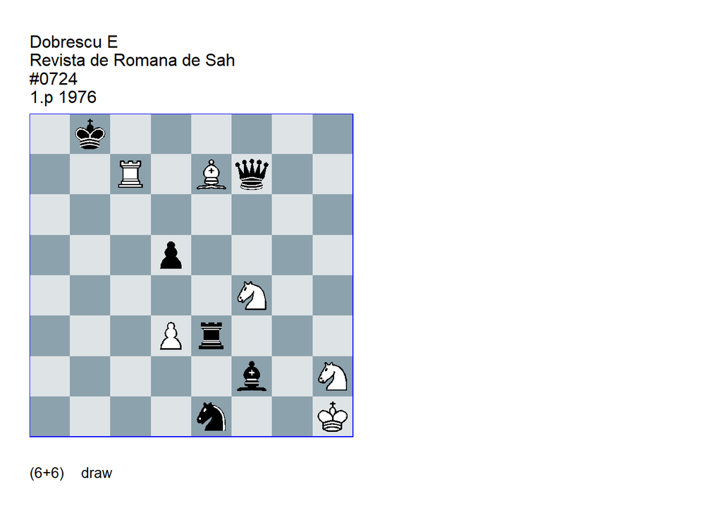

GBR: =3445.11h1b8 U3 FEN: 1k6/2R1Bq2/8/3p4/5N2/3Pr3/5b1N/4n2K w - - 0 1

Revista de Romana de Sah/6 9.p Rumanian champ 1976-1977 Revista de Romana de Sah/1 1979 (EG#03517). U3 Neuenschwander=B beatochess (web) no.15 02/2026. **1. Bd6 Qf6** (1… Qe8! **cook** **BN** 2. Re7+ Ka8 3. Rxe8+ Rxe8 4. Nxd5 Rg8) **2. Rc6+** (2. Rd7+? Ka8 3. Nxd5 Qxd6! (3… Qd4? 4. Nc7+ Kb7 5. Nb5+ Kc6 6. Nxd4+ Kxd7 7. Bc5) 4. Rxd6 Rg3!) **2… Kb7 3. Rb6+!** (3. Rc7+? Ka6 4. Rc6+ Kb5 5. Rb6+ Ka4! 6. Rb4+ Ka3 7. Rb6+ Ka2 8. Ra6+ Kb1 9. Rb6+ Kc2 10. Rc6+ Kd1!) **3… Ka8 4. Ra6+** (4. Nxd5? Qd8) **4… Kb7 5. Rb6+ Ka7 6. Bc5!** (6. Bb8+? Kxb6 7. Nxd5+ Kb7 8. Nxf6 Kxb8) (6. Nxd5? Qh8! 7. Bc5 (7. Bb8+ Qxb8 8. Rxb8 Bg3) 7… Rh3 8. Rh6+ Bxc5) (6. Nxd5) **6… Qc3 7. Rc6+!** (7. Rb5+? Ka8 8. Nxd5 Qg7!) **7… Kb7 8. Rc7+!** (8. Rb6+? Kc8 9. Rc6+ Kd7 10. Rd6+ Ke8) **8… Ka8 9. Rc8+ Kb7 10. Rc7+ Kb8** (10… Kxc7! **cook** **BN** 11. Nxd5+ Kc6 12. Nxc3 Kxc5 13. Ne4+ Kd4 14. Nxf2 Rg3) **11. Bd6 Qf6 12. Rc6+ 1/2-1/2**.

### 2.1.21 Kozdon =0473.34e7h8 (1977). Changed solution

The study is correct if the move order is changed.

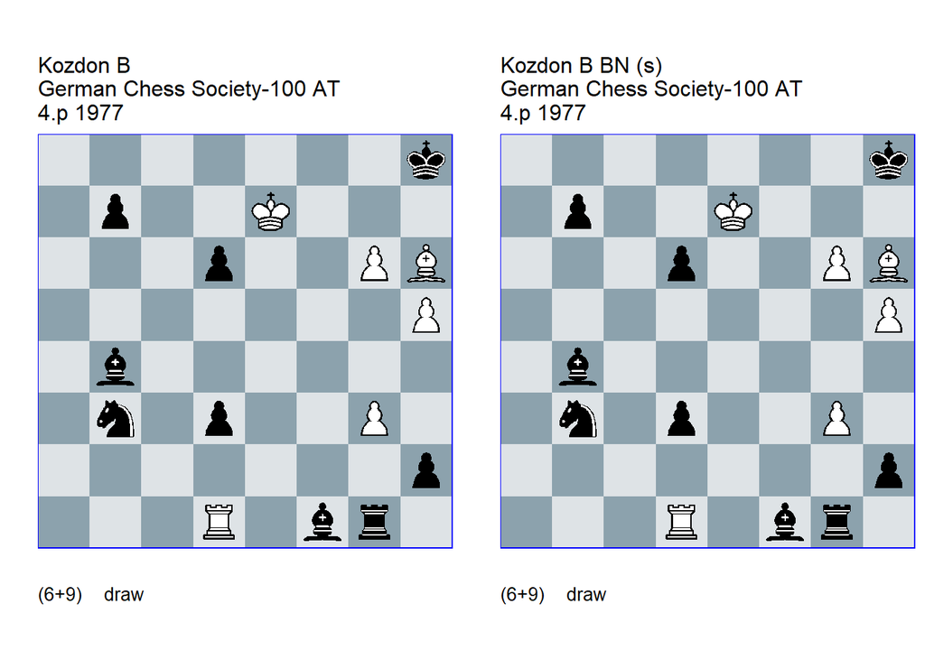

GBR: =0473.34e7h8 U4 FEN: 7k/1p2K3/3p2PB/7P/1b6/1n1p2P1/7p/3R1br1 w - - 0 1

(EG#03511). U4: 200 Estudios - Mundial 1968-1977#197 2004. **1. Ra1!** (1. Kf7? Bc3 2. Ra1 Bxa1) **1… Nxa1** (1… d5+ 2. Kf7 Bc3 (2… Bf8 3. Ra8) 3. Ra8#) **2. Kf7 Bc3 3. Bd2! Be5** (3… Bxd2 4. g7+) (3… Bg7 4. h6 Bb2 5. g7+) (3… Bf6 4. Bg5 Bb2 5. h6 h1=Q 6. g7+) **4. Bf4! Bb2** (4… Rxg3 5. Bxg3 Bg7 6. h6! Bxh6 7. Bxd6 Bg7 8. Bf8) **5. Bc1** (5. h6! **cook** 5… Rxg3 6. Bxg3) **5… Bc3 6. Bd2 Bd4 7. Be3 Be5 8. Bf4 Rxg3** (8… Bb2 9. Bc1) **9. Bxg3** (9. Bxe5+? dxe5 10. g7+ Rxg7+) **9… Bg7** (9… Bb2 10. h6 h1=Q 11. g7+ Bxg7 12. hxg7+) **10. h6! Bxh6 11. Bxd6 Bg7 12. Bf8! Bb2** (12… Bxf8 13. Kxf8 h1=Q (13… d2 14. g7+ Kh7 15. g8=Q+ Kh6 16. Qg7+ Kh5 17. Qf7+ Kg5 18. Qxf1) 14. g7+ Kh7 15. g8=Q+ Kh6 16. Qg7+ Kh5 17. Qh7+ Kg5 18. Qxh1) **13. Ba3 Bc3 14. Bb4 Bd4 15. Bc5 Be5 16. Bd6 Bf6 17. Be7 Bg7 18. Bf8 Bb2 19. Ba3 1/2-1/2**.

GBR: =0473.34e7h8 S FEN: 7k/1p2K3/3p2PB/7P/1b6/1n1p2P1/7p/3R1br1 w - - 0 1

(EG#03511). Changed solution: Neuenschwander=B beatochess (web) no.15 02/2026. **1. Ra1!** (1. Kf7? Bc3 2. Ra1 Bxa1) **1… Nxa1** (1… d5+ 2. Kf7 Bc3 (2… Bf8 3. Ra8) 3. Ra8#) **2. Kf7 Bc3 3. Bd2! Bb2 4. Bc1! Bd4 5. Be3! Be5 6. Bf4 Rxg3 7. Bxg3 Bg7 8. h6 Bxh6 9. Bxd6 Bg7 10. Bf8 Bb2 11. Ba3 Bc3 12. Bb4 Bd4 13. Bc5 Be5 14. Bd6 Bf6 15. Be7 Bg7 16. Bf8 1/2-1/2**.

### 2.1.22 Kuznetsov & Sidorov +0408.12d3b1 (1976). Cook

**4. Rc5!** cooks the original and the correction.

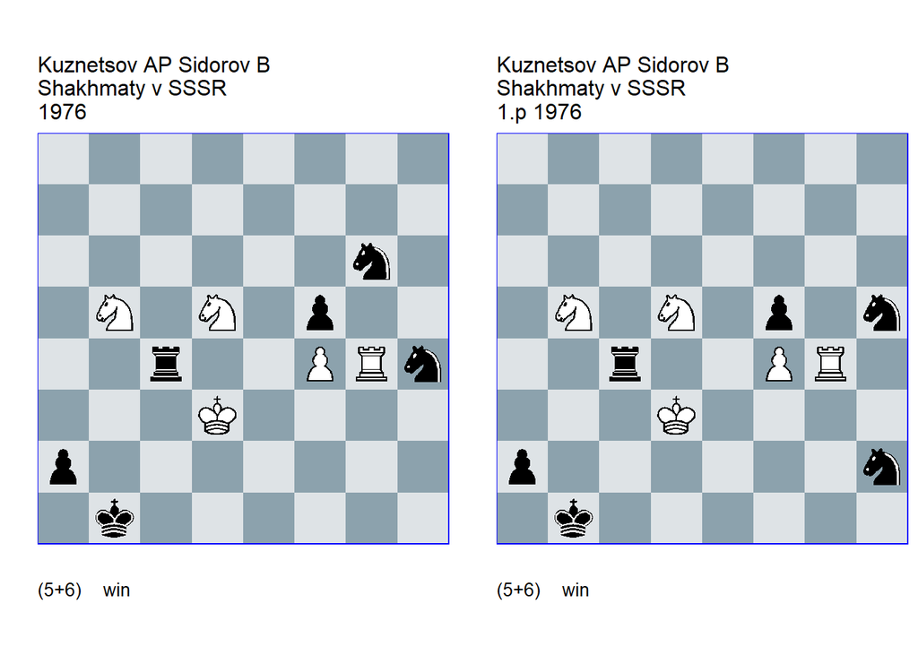

GBR: +0408.12d3b1 TT U3 U2 FEN: 8/8/6n1/1N1N1p2/2r2PRn/3K4/p7/1k6 w - - 0 1

(EG#03503). U3: Nunn=J EG=61 7/1980: U2: Neuenschwander=B beatochess (web) no.15 02/2026. **1. Na3+ Ka1 2. Rg1+ Rc1 3. Rxc1+ Kb2 4. Ra1** (4. Rc5! **cook** **BN** 4… a1=Q 5. Nc4+ Kc1 6. Na5+ Kd1 (6… Kb2 7. Rb5+) 7. Ne3+) **4… Nxf4+** ( 4… Kxa1! **cook** JN 5. Kc2 Nf3 6. Kc1 Nd4 7. Nc2+ Nxc2 8. Kxc2 Nxf4) **5. Nxf4 Kxa1 6. Kc2 Nf3 7. Kc1 Nd4 8. Nc2+ Nxc2 9. Ne6 Nb4 10. Nc5 f4** eg **11. Nb3# 1-0**.

GBR: +0408.12d3b1 TT C U2 FEN: 8/8/8/1N1N1p1n/2r2PR1/3K4/p6n/1k6 w - - 0 1

correction: Shakhmaty v SSSR/4 1979. U2: Neuenschwander=B beatochess (web) no.15 02/2026. **1. Na3+ Ka1! 2. Rg1+ Rc1! 3. Rxc1+ Kb2 4. Ra1!** (4. Rc5! **cook** **BN** 4… a1=Q (4… Kxa3 5. Kc2) 5. Nc4+ Kc1 6. Nd2+ Kd1 7. Ne3+ Ke1 8. Nc2+) **4… Nxf4+ 5. Nxf4 Kxa1 6. Kc2 Nf3 7. Kc1 Ne1! 8. Nc2+! Nxc2 9. Ne6 Nb4 10. Nc5 f4** eg **11. Nb3# 1-0**.

### 2.1.23 Kralin & Kuznetsov +0400.55g8e8 (1976). Cook, correction

**2. Kxh7** cooks the correction.

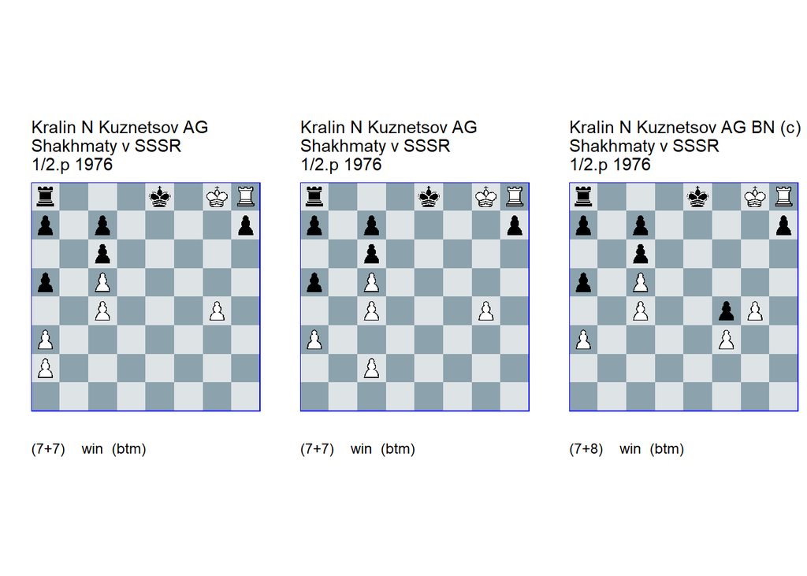

GBR: +0400.55g8e8 U3 FEN: r3k1KR/p1p4p/2p5/p1P5/2P3P1/P7/P7/8 b q - 0 1

Shakhmaty v SSSR/1 (EG#03481). U3: Reiners=J 0-0=3 1981. **1… O-O-O+!** (1… Kd7+ 2. Kxh7 Rxh8+ 3. Kxh8 a4 4. g5 Kc8 5. g6 Kb7 6. g7 Ka6 7. g8=Q) **2. Kg7!** (2. Kxh7? Rxh8+ 3. Kxh8 a4!) **2… Rxh8 3. Kxh8 a4** (3… h6 4. a4!) **4. g5! Kb7! 5. Kg8!** (5. Kg7? h6 6. gxh6 Ka6 7. h7 Ka5 8. h8=Q a6 9. Qh1) **5… h5** (5… Kc8 6. Kg7! (6. Kxh7? Kb7!) 6… Kb7 (6… Kd7 7. Kxh7) 7. Kf7 Kc8 8. Ke7 Kb8 9. Kd8 Kb7 10. Kd7 Kb8 11. Kxc6 Kc8 12. Kb5 Kd7 13. Kxa4 Kc6 14. Kb4 a5+ 15. Kxa5 Kxc5 16. a4 Kxc4 17. Ka6 Kb4 (17… Kd3 18. Kb5! Kd4 19. Kc6 Kc4 20. a5) (17… Kd5 18. Kb5! c5 19. a5 c4 20. a6 c3 21. a7 c2 22. a8=Q+) (17… Kd4! **cook** JR 18. Kb5 c5 19. a5 c4 20. a6 c3 21. a7 c2 22. a8=Q c1=Q) 18. a5 c5 19. Kb6 c4 20. a6 c3 21. a7 c2 22. a8=Q c1=Q 23. Qa5+ Kc4 24. Qc5+ Kd3 25. Qxc1) **6. gxh6 Ka6 7. h7 Ka5 8. h8=Q a6 9. Qc3# 1-0**.

GBR: +0400.55g8e8 C U2 FEN: r3k1KR/p1p4p/2p5/p1P5/2P3P1/P7/2P5/8 b q - 0 1

Shakhmaty v SSSR/1. correction: Rothwell=S Keym=W Konig & Turm=17 9/2005. U2: Neuenschwander=B beatochess (web) no.15 02/2026. **1… O-O-O+!** (1… Kd7+ 2. Kxh7 Rxh8+ 3. Kxh8 a4 4. g5 Kc8 5. g6 Kb7 6. g7 Ka6 7. g8=Q Ka5 8. Qb8) **2. Kg7!** (2. Kxh7? Rxh8+ 3. Kxh8 a4! 4. g5 Kb7 5. g6 Ka6 6. g7 Ka5 7. g8=Q a6 8. Qg1 (8. Qd5! **cook** **BN** 8… cxd5 9. cxd5 Kb5 10. c6 Kc5 11. c4) ) **2… Rxh8 3. Kxh8 a4** (3… h6 4. a4!) **4. g5!** (4. Kxh7? Kb7!) (4. Kg8? h6!) (4. Kg7? h6!) **4… Kb7! 5. Kg8!** (5. Kg7? h5! 6. gxh6 Ka6 7. h7 Ka5 8. h8=Q a6 9. Qh1) **5… h5** (5… Kc8 6. Kg7! Kb7 7. Kf7 Kc8 8. Ke7 Kb8 9. Kd8 Kb7 10. Kd7 Kb8 11. Kxc6 Kc8 12. Kb5 Kd7 13. Kxa4 Kc6 14. Kb4 a5+ 15. Kxa5 Kxc5 16. a4 Kxc4 17. Ka6 Kb4 18. a5 c5 19. Kb6 c4 20. a6) (5… Ka8 6. Kf7 Kb7 7. Ke7 Kc8 8. Ke8) **6. gxh6 Ka6 7. h7 Ka5 8. h8=Q** (8. h8=B or ) **8… a6 9. Qc3# 1-0**.

GBR: +0400.56g8e8 C FEN: r3k1KR/p1p4p/2p5/p1P5/2P2pP1/P4P2/8/8 b q - 1 1

correction: Neuenschwander=B beatochess (web) no.15 02/2026. **1… O-O-O+ 2. Kg7!** (2. Kxh7? Rxh8+ 3. Kxh8 a4 4. g5 Kb7 5. g6 Ka6 6. g7 Ka5 7. g8=Q a6) **2… Rxh8 3. Kxh8 a4 4. g5 Kb7 5. Kg8!** (5. Kg7? h5 6. gxh6 Ka6 7. h7 Ka5 8. h8=Q a6) **5… h5 6. gxh6 Ka6 7. h7 Ka5 8. h8=Q a6 9. Qc3# 1-0**.

### 2.1.24 Bordeniuk +0303.65b8a4 (1975). Cook, version

**11. Kd5!** is an additional cook. The version ends in a slightly different way.

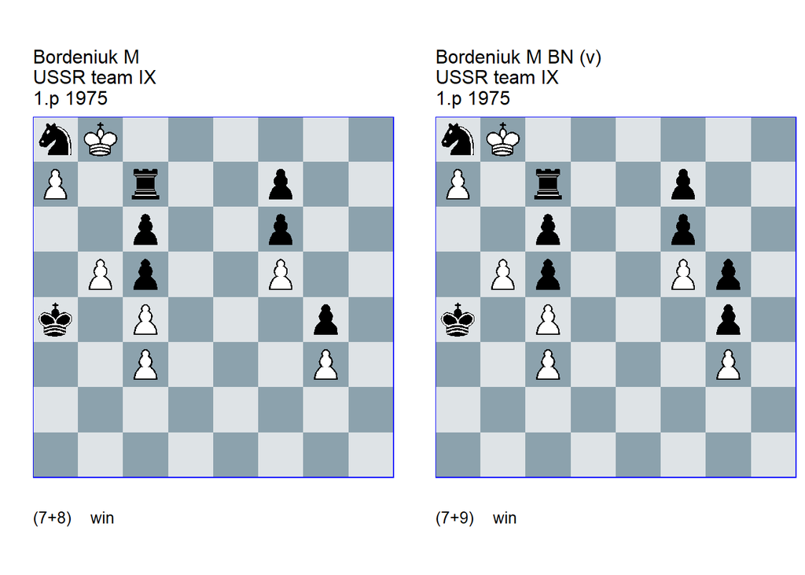

GBR: +0303.65b8a4 TT U2 FEN: nK6/P1r2p2/2p2p2/1Pp2P2/k1P3p1/2P3P1/8/8 w - - 0 1

USSR team champ IX 1975-1976 (EG#03435). U2: Garcia=M HHdbIV#42370 19-1-2007. U2: Neuenschwander=B beatochess (web) no.15 02/2026. **1. b6 Rd7! 2. Kxa8 Ka5 3. b7 Rd8+ 4. b8=R!** (4. b8=Q? Ka6 5. Qxd8) **4… Rd7 5. Rb3!** (5. Rb1! **cook** MG 5… Ka6 6. Kb8 Rxa7 7. Kc8 Re7 8. Kd8 Re4 9. Kc7 Rxc4 10. Kxc6 Ka7 11. Rb3 Re4 12. Rb7+ Ka6 13. Rxf7 Re3 14. Rxf6 Rxg3 15. Rg6 Rf3 16. Rxg4 Ka7 17. Rg7+ Ka6 18. Rg8 Ka7 19. Rf8) **5… Ka6 6. Kb8 Rxa7! 7. Kc8!** (7. Ra3+? Kb6! 8. Rxa7) **7… Re7 8. Kd8 Re4 9. Kc7 Rxc4 10. Kxc6 Ka7 11. Ra3+** (11. Kd5! **cook** **BN** 11… Ra4 12. Kxc5) **11… Kb8 12. Kd5 1-0**.

GBR: +0303.66b8a4 TT V FEN: nK6/P1r2p2/2p2p2/1Pp2Pp1/k1P3p1/2P3P1/8/8 w - - 0 1

USSR team champ IX 1975-1976 (EG#03435). version: Neuenschwander=B beatochess (web) no.15 02/2026. **1. b6 Rd7! 2. Kxa8 Ka5 3. b7 Rd8+ 4. b8=R!** (4. b8=Q? Ka6 5. Qxd8) **4… Rd7 5. Rb3!** (5. Rb1? Ka6 6. Kb8 Rxa7 7. Kc8 Re7 8. Kd8 Re4 9. Kc7 Rxc4 10. Kxc6 Ka7) **5… Ka6 6. Kb8 Rxa7! 7. Kc8!** (7. Ra3+? Kb6! 8. Rxa7) **7… Re7 8. Kd8 Re4 9. Kc7 Rxc4 10. Kxc6 Ra4** (10… Ka7 11. Ra3+ Kb8 12. Kd5) **11. c4! 1-0**.

### 2.1.25 Yakimchik =0143.12c1g8 (1975). Cooks

Black is winning after **1… f5**, **1… Bf3**, or **1… Ne3**.

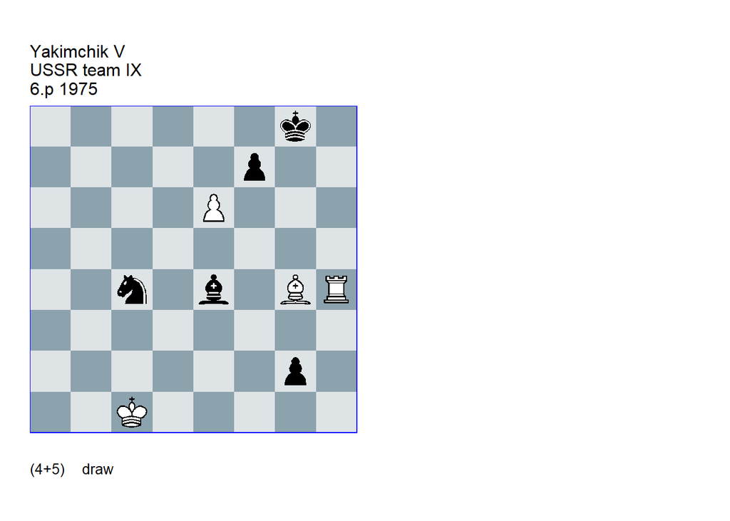

GBR: =0143.12c1g8 TT U3 FEN: 6k1/5p2/4P3/8/2n1b1BR/8/6p1/2K5 w - - 0 1

USSR team champ IX 1975-1976 (EG#03425). U3: Neuenschwander=B beatochess (web) no.15 02/2026. **1. Bd1! Bf5!** (1… f5! **cook** **BN** ) (1… Bf3! **cook** **BN** ) (1… Ne3! **cook** **BN** ) **2. exf7+ Kg7 3. Rh8! Kxf7 4. Rh1! gxh1=B** (4… gxh1=N main 5. Bf3 Ng3 6. Bd5+ Kf6 7. Bxc4) (4… gxh1=Q) **5. Bb3 Bd5 6. Bxc4 1/2-1/2**.

### 2.1.26 Kuznetsov =0514.12e5e8 (1974). Correction

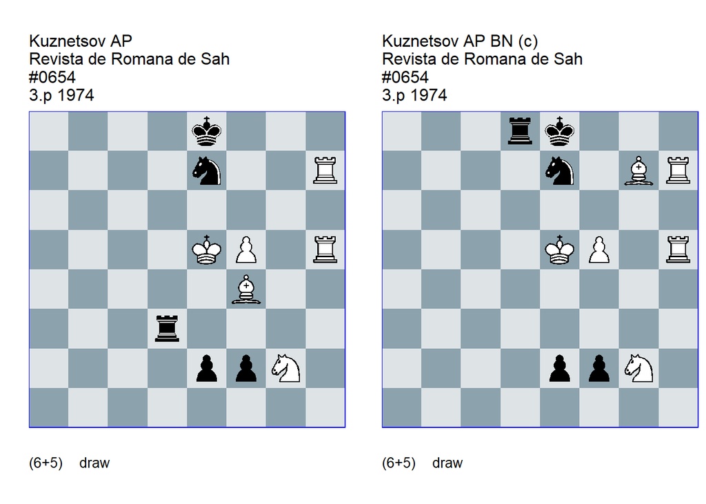

GBR: =0514.12e5e8 U1 FEN: 4k3/4n2R/8/4KP1R/5B2/3r4/4ppN1/8 w - - 0 1

Revista de Romana de Sah/5 (EG#03395). U1: Garcia=M HHdbV#40983 6-2-2009. **1. Ke6** (1. Ne1! **cook** MG 1… fxe1=Q (1… f1=Q 2. Ke6) 2. Ke6 Ng8 3. Rg5 Qg3 4. Bxg3 Rxg3 5. Rxg8+ Rxg8 6. Rh1) (1. Rxe7+! **cook** MG 1… Kxe7 2. Rh7+ Kf8 3. Kf6 Ke8 4. Ke6 e1=Q+ 5. Nxe1 fxe1=Q+ 6. Be5) **1… e1=Q+** (1… Ng8 2. Rg7 Kf8 3. Rf7+ Ke8 4. Rg7) **2. Nxe1 fxe1=Q+ 3. Be5 Rd6+!** (3… Ng8 4. Rg7 Rd6+ 5. Kxd6 Qb4+ 6. Ke6 Qc4+ 7. Kd6 Qa6+ 8. Kd5 Ne7+ 9. Rxe7+) **4. Kxd6 Qd2+ 5. Ke6 Qd5+ 6. Kf6 Ng8+ 7. Kg7 Qxe5+ 8. Kxg8 Qd5+ 9. Kh8!** (9. Kg7? Qf7+ 10. Kh6 Qf6#) **9… Kf8 10. Rg7!** (10. Rg5? Qd4+ 11. Rhg7 (11. Rgg7 Qf6) 11… Qh4+ 12. Rh7 Qxg5) **10… Qd4! 11. f6! Qxf6 12. Rf5! Qxf5 13. Rf7+ Kxf7** ( 13… Qxf7) **1/2-1/2**.

GBR: =0514.12e5e8 C FEN: 3rk3/4n1BR/8/4KP1R/8/8/4ppN1/8 w - - 0 1

correction: Neuenschwander=B beatochess (web) no.15 02/2026. **1. Ke6** (1. Rh8+? Kd7 2. Rxd8+ Kxd8 3. Kd6 Ke8) **1… e1=Q+ 2. Nxe1 fxe1=Q+ 3. Be5 Rd6+!** ( 3… Ng8 4. Rg7 Rd6+ 5. Kxd6 Qb4+ 6. Ke6 Qc4+ 7. Kd6 Qa6+ 8. Kd5 Ne7+ 9. Rxe7+) **4. Kxd6 Qd2+ 5. Ke6 Qd5+ 6. Kf6 Ng8+ 7. Kg7 Qxe5+ 8. Kxg8 Qd5+ 9. Kh8!** (9. Kg7? Qf7+ 10. Kh6 Qf6#) **9… Kf8 10. Rg7!** (10. Rg5? Qd4+ 11. Rhg7 (11. Rgg7 Qf6) 11… Qh4+ 12. Rh7 Qxg5) **10… Qd4! 11. f6! Qxf6 12. Rf5! Qxf5 13. Rf7+ Kxf7** (13… Qxf7) **1/2-1/2**.

### 2.1.27 Zinar +0000.44f7e5 (1977). Comment, cook, correction

- The study has six thematic mainlines; see **EG no. 53** (page 58). The line **1… fxg4 2. d6 g4 3. g3 d7 g2** is not marked as a mainline in **HHdbVI**.
- The main problem is that two of the mainlines are cooked.
- The correction seems to fix the study. Of note: there is a 7th promotion (on b1). However, since the win is not thematic (i.e., not achieved by winning the black queen), I consider this a sideline. A version with 7 thematic promotions seems hard to achieve.

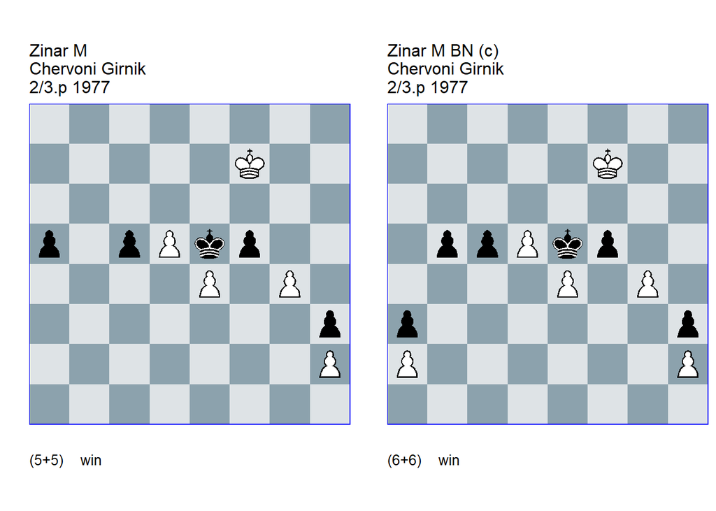

GBR: +0000.44f7e5 U2 FEN: 8/5K2/8/p1pPkp2/4P1P1/7p/7P/8 w - - 0 1

(EG#03384). comment, U2: Neuenschwander=B beatochess (web) no.15 02/2026. **1. Ke7!** (1. g5? f4!) **1… a4** (1… c4 main 2. d6 c3 3. d7 c2 4. d8=Q c1=Q 5. Qd5+ Kf4 6. Qxf5+ (6. gxf5 **cook** **BN** ) (6. exf5 **cook** **BN** ) 6… Ke3 7. Qg5+ Kxe4 8. Qxc1) (1… fxe4 main 2. d6 e3 3. d7 e2 4. d8=Q e1=Q 5. Qd6+ Ke4 6. Qe6+ Kf3 7. Qxe1) (1… f4 main 2. d6 f3 3. d7 f2 4. d8=Q f1=Q 5. Qd5+ Kf4 6. Qf5+ (6. Qf7+ or ) 6… Ke3 7. Qxf1) (1… fxg4 main 2. d6 g3 3. d7 gxh2 (3… g2 main **BN** 4. d8=Q g1=Q 5. Qd5+ Kf4 6. Qf5+ Ke3 7. Qxc5+) 4. d8=Q h1=Q 5. Qd6+ Kxe4 6. Qc6+ Kd4 7. Qxh1) **2. d6** (2. exf5! **cook** **BN** 2… a3 3. d6 a2 4. d7 a1=Q 5. d8=Q) **2… a3 3. d7 a2 4. d8=Q a1=Q 5. Qh8+ Kxe4 6. Qxa1 1-0**.

GBR: +0000.55f7e5 C FEN: 8/5K2/8/1ppPkp2/4P1P1/p6p/P6P/8 w - - 0 1

(EG#03384). Correction: Neuenschwander=B beatochess (web) no.15 02/2026. . **1. Ke7!** (1. g5? f4! 2. g6 f3 3. g7 f2 4. g8=Q f1=Q+ 5. Ke8 Qf6) **1… b4** ( 1… c4 main 2. d6 c3 3. d7 c2 4. d8=Q c1=Q 5. Qd5+ Kf4 6. Qxf5+ (6. exf5? Qc7+ 7. Kf8 b4 8. f6 b3) 6… Ke3 7. Qg5+ Kxe4 8. Qxc1) (1… fxe4 main 2. d6 e3 3. d7 e2 4. d8=Q e1=Q 5. Qd6+ Ke4 6. Qe6+ Kf3 7. Qxe1) (1… f4 main 2. d6 f3 3. d7 f2 4. d8=Q f1=Q 5. Qd5+ Kf4 6. Qf5+ (6. Qf7+ or ) 6… Ke3 7. Qxf1) (1… fxg4 main 2. d6 g3 3. d7 gxh2 (3… g2 main 4. d8=Q g1=Q 5. Qd5+ Kf4 6. Qf5+ Ke3 7. Qxc5+) 4. d8=Q h1=Q 5. Qd6+ Kxe4 6. Qc6+ Kd4 7. Qxh1) **2. d6 b3 3. d7 bxa2** (3… b2 4. d8=Q b1=Q 5. Qd5+ Kf4 6. gxf5) **4. d8=Q a1=Q 5. Qh8+ Kxe4 6. Qxa1 1-0**.